# Clustering : Classif non supervisée

Groupe 5 (Maeva, Matéo, Mélina, Marine, Anna)

2025-11-24

# 1 Introduction et overview

## 1.1 Qu’est-ce que la classification non supervisée ?

La classification non supervisée est une méthode d’analyse qui vise à regrouper des objets (individus, produits, observations, etc.) en classes homogènes, sans connaître à l’avance ces classes. Contrairement à la classification supervisée, il n’y a pas de variable à prédire : on cherche simplement à découvrir des structures cachées dans les données.

## 1.2 Pourquoi faire de la classification ?

L’objectif est de réduire la complexité d’un jeu de données en mettant en évidence des structures internes qui permettent de comprendre les données : On simplifie la lecture et l’interprétation. On identifie des groupes d’objets similaires.

On retrouve une logique proche de l’analyse factorielle, qui réduit la dimension, mais ici on réduit la diversité des profils Pour classer, il faut pouvoir mesurer la proximité entre objets : c’est le rôle de la distance métrique (euclidienne, Manhattan, etc.).

« Qui dit distance métrique dit contrainte spatiale » Autrement dit, chaque individu est un point dans un espace à plusieurs dimensions et la distance traduit sa ressemblance avec un autre point.

## 1.3 Matrice des distances / dissimilarités

La « structure » des données est une vue bien particulière sur les objets. Elle est définie par une notion de distances entre les objets, le principe de la classification non supervisée étant de regrouper des objets similaires (donc peu distants, ou « proches ») et de distinguer les objets différents ( « éloignés » les uns des autres). La classification non supervisée fait donc appel à une notion de distance (dont le choix est primordial) qui est la base de la classification d’objets.

Les données d’entrée d’un algorithme de classification peuvent être :

- un **tableau individus × variables** (n × p),

- une **matrice de distances** entre individus.

La matrice des distances est donc un point de départ possible de tout algorithme de classification. C’est une matrice carrée de taille n × n qui contient toutes les distances entre paires d’objets.

Cette matrice peut être une matrice de :

- distance , qui mesure l’écart entre deux objets (dans un espace donné)

- dissimilarité, qui mesure le degré de différence entre 2 objets donnés

## 1.4 Critères d’agrégation

En classification hiérarchique, on utilise un critère d’agrégation pour décider comment fusionner les groupes. On ne se place plus au niveau des individus, mais au niveau des aggrégats d’individus.

## 1.5 Critère de classification

La classification d’objet peut être déterministe ou “dure”, c’est à dire qu’un objet ou individu va être assigné à l’appartenance à une classe uniquement, ou elle peut être probabiliste ou “floue”, c’est à dire que l’appartenance de l’individu ou de l’objet à une classe sera associée à une probabilité d’appartenance à cette classe, la somme de toutes les probabilités d’appartenance d’un individu à l’ensemble des classes étant de 1.

## 1.6 Stratégie de classification

Il existe différents types de stratégie de classification : le partitionnement direct et la classification ascendante hierarchique (et les stratégies mixtes qui les combinent). En partitionnement direct, le nombre de clusters K en lequel les objets seront divisés est déterminé à l’avance.

La classification hiérarchique ascendante (CAH) est une méthode agrégative, où on part de n classes (chaque individu seul), on fusionne à chaque étape les classes les plus proches et on obtient un dendrogramme (ou arbre hiérarchique) qui montre les niveaux de regroupement, que l’on peut ensuite couper à différents niveaux pour obtenir la finesse de la partition souhaitée.

Cette méthode est adaptée aux variables quantitatives (une variable correspond à une dimension) et aux variables qualitatives (une modalité correspond à une dimension).

## 1.7 De la classification aux lois de mélanges

On s’intéresse au processus génératif de données, dans le cadre de lois de mélanges de gaussiennes multidimensionnelles. On se demande si on peut retrouver le processus qui a permis d’aboutir à la génération de données dans un cas simple (mélange de gaussiennes multidimensionnelles). L’objectif est d’appliquer des algorithmes d’optimisation afin d’obtenir les paramètres les plus vraisemblables, ayant pu permettre de générer ces données. On estime ces paramètres grâce aux données elles-mêmes. Ces algorithmes d’optimisation sont basés sur le théorème de Bayes. La probabilité d’appartenance à une classe peut être modélisée comme une variable latente.

## 1.8 Des lois de mélange aux topic modelling

Le *topic modelling* est une méthode de classification non supervisée appliquée aux textes.

On cherche à comprendre le processus génératif d’un document, en applicant les méthodes évoquées précédemment. L’objectif est de savoir comment un document à été généré. Or, on peut définir un document comme une distribution de topics (les sujets dont il est composé), associés à des proportions spécifiques. De plus, un topic est défini comme une distribution aléatoire de mots. On cherche a faire du reverse engineering et retrouver, à partir de documents, les processus qui ont permis leur génération.

Un **topic** (ou « sujet ») correspond à une **distribution de mots récurrents** dans un corpus.

Les objectifs sont :

- Estimer la **proportion de chaque topic dans chaque document**.  
- Identifier les **mots caractéristiques** associés à chaque topic.

# 2 Seance 1

On cherche à réaliser la classification de variables issus du jeu de données “décathlon” (FactoMineR) en utilisant uniquement 10 premières variables du jeu de données, et par calcul matriciel uniquement.

On se questionne donc sur la notion de distances entre les objets.

La distance entre deux variables doit pouvoir mettre en évidence que deux variables sont proches l’une de l’autre, ou que deux variables sont éloignées l’une de l’autre. Les variables étant des mesures sur les individus, si deux variables sont proches, alors, les valeurs prises par les individus sur ces deux variables reflètent une proximité entre ces variables.

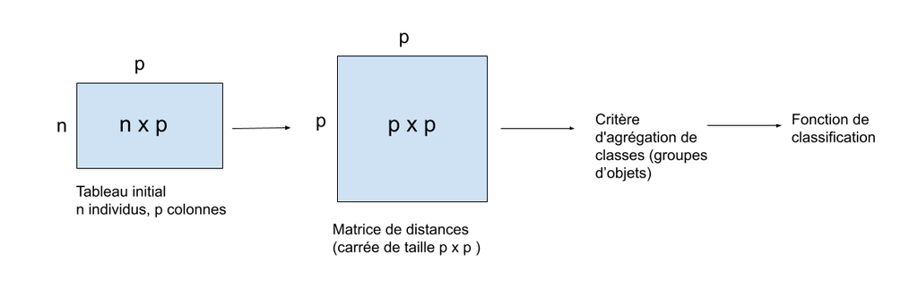

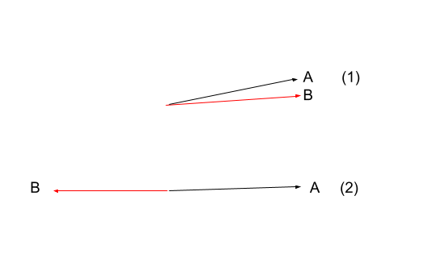

Les variables A et B sont-elles proches dans la situation 1 ? Oui, car les valeurs prises par les individus pour la variable A et pour la variable B se comportent de la même manière : les individus qui ont tendance à prendre des fortes valeurs pour la variable A ont tendance à prendre aussi des fortes valeurs pour la variable B (ou de faibles valeurs,…. ). Et dans la situation 2?

Dans la situation 2, les individus qui vont avoir tendance à prendre des fortes valeurs pour la variable B prendront plutôt des faibles valeurs sur la variable A, et inversement. On peut considérer que l’information transmise par ces deux variables peut être représentée de façon unidimensionnelle (par exemple : A : faire bcp de sport, B : ne pas faire de sport) et donc que l’opposition entre les variables A et B traduit une proximité entre elles.

Pour traduire cette distance entre les variables, on peut calculer la matrice des covariances de p (matrice de variance covariance) :

$$\operatorname{Cov}(X, Y) =
\frac{\sum_{i=1}^{N} (x_i - \bar{x})(y_i - \bar{y})}{n}$$

Comme Cov(X,X) = Var(X) ; en diagonale de la matrice de variance-covariances se trouvent les variances des variables 1 à n :

$$V =
\begin{pmatrix}
V(X_1) & \operatorname{Cov}(X_1, X_2) & \cdots &
\operatorname{Cov}(X_1, X_n) \\
\operatorname{Cov}(X_2, X_1) & V(X_2) & \cdots &
\operatorname{Cov}(X_2, X_n) \\
\vdots & \vdots & \ddots & \vdots \\
\operatorname{Cov}(X_n, X_1) & \operatorname{Cov}(X_n, X_2) &
\cdots & V(X_n)
\end{pmatrix}$$

A partir de cette matrice V, on peut calculer la matrice des p (coefficients de corrélation de pearson), en pondérant par la diagonale de la matrice de variance - covariance (pondération par le produit des racines carrées des variances).

La formule de la corrélation étant :
$$\rho(X, Y)
=
\frac{\sum (X - \bar{X})(Y - \bar{Y})}
{\sqrt{\sum (X - \bar{X})^{2}} \, \sqrt{\sum (Y - \bar{Y})^{2}}}
=
\frac{\operatorname{Cov}(X, Y)}
{\sqrt{V(X)} \, \sqrt{V(Y)}}$$

X et Y : deux variables aléatoires

$\bar{X}$ et $\bar{Y}$: moyennes respectives des variables X et Y

$\operatorname{Cov}(X, Y)$ : Covariance entre X et Y

$V(X)$ et $V(Y)$ : Variances respectives de X et Y

On obtient la matrice des coefficients de corrélation. On passe ensuite tous les éléments de cette matrice au carré, pour obtenir des coefficients de corrélation entre 0 et 1.

Pour obtenir la matrice des distances, on crée la matrice des (1 - p²) : Si on s’intéresse à une variable X et une autre variable X’, si X = X’, alors leur p² est de 1 donc leur distance dx’x est de 0 : deux variables identiques sont en effet confondues donc aucunement distantes. Plus la distance entre deux variables X et X’ est importante, plus la valeur au croisement de X et X’ dans la matrice des distances est proche de 1.

Cette matrice de distance de taille p x p permettra ensuite de réaliser la classification des variables à partir du critère d’agrégation défini.

Nous allons voir la mise en oeuvre avec le jeu de données “décathlon”.

## 2.1 Récupération des données

```r
library(FactoMineR)
data("decathlon")
data <- decathlon
data <- data[,1:10]

summary(data)
```

```
##       100m         Long.jump       Shot.put       High.jump          400m
##  Min.   :10.44   Min.   :6.61   Min.   :12.68   Min.   :1.850   Min.   :46.81
##  1st Qu.:10.85   1st Qu.:7.03   1st Qu.:13.88   1st Qu.:1.920   1st Qu.:48.93
##  Median :10.98   Median :7.30   Median :14.57   Median :1.950   Median :49.40
##  Mean   :11.00   Mean   :7.26   Mean   :14.48   Mean   :1.977   Mean   :49.62
##  3rd Qu.:11.14   3rd Qu.:7.48   3rd Qu.:14.97   3rd Qu.:2.040   3rd Qu.:50.30
##  Max.   :11.64   Max.   :7.96   Max.   :16.36   Max.   :2.150   Max.   :53.20
##   110m.hurdle        Discus        Pole.vault       Javeline
##  Min.   :13.97   Min.   :37.92   Min.   :4.200   Min.   :50.31
##  1st Qu.:14.21   1st Qu.:41.90   1st Qu.:4.500   1st Qu.:55.27
##  Median :14.48   Median :44.41   Median :4.800   Median :58.36
##  Mean   :14.61   Mean   :44.33   Mean   :4.762   Mean   :58.32
##  3rd Qu.:14.98   3rd Qu.:46.07   3rd Qu.:4.920   3rd Qu.:60.89
##  Max.   :15.67   Max.   :51.65   Max.   :5.400   Max.   :70.52
##      1500m
##  Min.   :262.1
##  1st Qu.:271.0
##  Median :278.1
##  Mean   :279.0
##  3rd Qu.:285.1
##  Max.   :317.0
```

Calcul du vecteur des moyennes

```r
moy_matr <- matrix(1, nrow = nrow(data), ncol = ncol(data) ) # construction de la matrice des moyennes de dimension n (41) x p (10)

# transforme data en matrice
data <- as.matrix(data)

# création de la matrice NxP des moyennes
for (i in 1:nrow(data)) {
  moy_col <- colMeans(data) #  récupération des moyennes par colonne de data
  moy_matr[i,] <- moy_col   #  chaque colonne p(i) contient la moyenne de la colonne  i
}

# Création de la matrice X centrée => X_Centrée = X (=data) - X_moyenne (=moy_matr)
X_centree = data - moy_matr

# test : data[1,1] - 11

X_centree # dim N * P
```

```
##                    100m Long.jump     Shot.put    High.jump        400m
## SEBRLE       0.04195122      0.32  0.352926829  0.093170732  0.19365854
## CLAY        -0.23804878      0.14 -0.217073171 -0.116829268 -0.24634146
## KARPOV       0.02195122      0.04  0.292926829  0.063170732 -1.24634146
## BERNARD      0.02195122     -0.03 -0.227073171 -0.056829268 -0.68634146
## YURKOV       0.34195122     -0.17  0.712926829  0.123170732  0.80365854
## WARNERS      0.11195122      0.34 -0.167073171  0.003170732 -0.93634146
## ZSIVOCZKY    0.13195122      0.04 -0.997073171  0.033170732 -0.99634146
## McMULLEN    -0.16804878      0.05 -0.717073171  0.153170732  0.29365854
## MARTINEAU    0.64195122     -0.45  0.092926829 -0.026829268  0.52365854
## HERNU        0.37195122      0.30 -0.067073171 -0.116829268  1.48365854
## BARRAS       0.33195122     -0.29 -0.387073171 -0.026829268 -0.13634146
## NOOL         0.33195122      0.01 -1.797073171  0.003170732 -0.41634146
## BOURGUIGNON  0.36195122     -0.46 -1.017073171 -0.116829268  1.54365854
## Sebrle      -0.14804878      0.58  1.882926829  0.143170732 -1.25634146
## Clay        -0.55804878      0.70  0.752926829  0.083170732 -0.42634146
## Karpov      -0.49804878      0.55  1.452926829  0.113170732 -2.80634146
## Macey       -0.10804878      0.21  1.252926829  0.173170732 -0.64634146
## Warners     -0.37804878      0.48  0.002926829 -0.006829268 -1.64634146
## Zsivoczky   -0.08804878     -0.12  0.832926829  0.143170732 -0.21634146
## Hernu       -0.02804878     -0.07  0.172926829  0.053170732 -0.88634146
## Nool        -0.19804878      0.27 -0.217073171 -0.096829268 -0.80634146
## Bernard     -0.30804878      0.22  0.322926829  0.143170732 -0.48634146
## Schwarzl    -0.01804878      0.23 -0.467073171 -0.036829268  0.14365854
## Pogorelov   -0.04804878      0.05  0.622926829  0.083170732  1.17365854
## Schoenbeck  -0.09804878      0.04  0.292926829 -0.096829268  0.68365854
## Barras       0.14195122     -0.27  0.432926829 -0.036829268 -0.20634146
## Smith       -0.14804878     -0.45  0.762926829 -0.066829268 -0.34634146
## Averyanov   -0.44804878      0.08 -0.037073171 -0.036829268  0.10365854
## Ojaniemi    -0.31804878      0.24  0.492926829 -0.036829268 -0.49634146
## Smirnov     -0.10804878     -0.19 -0.597073171 -0.036829268 -0.50634146
## Qi           0.06195122      0.08 -0.927073171 -0.006829268  0.03365854
## Drews       -0.12804878      0.12 -1.407073171 -0.096829268 -1.10634146
## Parkhomenko  0.14195122     -0.65  1.212926829  0.053170732  1.42365854
## Terek       -0.07804878     -0.32  0.672926829 -0.036829268 -0.05634146
## Gomez        0.08195122      0.00  0.092926829 -0.126829268 -1.00634146
## Turi         0.08195122     -0.35 -0.857073171  0.053170732  2.05365854
## Lorenzo      0.10195122     -0.23 -1.257073171 -0.126829268 -0.27634146
## Karlivans    0.33195122      0.00 -1.177073171 -0.006829268  0.92365854
## Korkizoglou -0.13804878     -0.19  0.332926829 -0.036829268  1.54365854
```

[output cut: 29 more lines]

```
## Smith       -0.59585366  4.69439024 -0.56243902  3.20341463  -6.284878
## Averyanov   -0.21585366 -4.44560976  0.03756098 -3.80658537  -8.004878
## Ojaniemi     0.40414634 -3.97560976 -0.16243902  0.94341463  -3.314878
## Smirnov      0.16414634 -1.85560976 -0.06243902  2.56341463 -15.714878
## Qi           0.17414634  0.80439024 -0.26243902  2.47341463  -6.394878
## Drews       -0.59585366 -4.21560976  0.23756098 -6.78658537  -4.814878
## Parkhomenko  0.27414634 -2.42560976  0.03756098  7.50341463  -1.084878
## Terek        0.51414634  1.29439024  0.53756098 -7.69658537  11.335122
## Gomez       -0.19585366 -3.37560976 -0.36243902  2.39341463  -9.324878
## Turi        -0.34585366 -4.49560976  0.03756098  1.02341463  10.985122
## Lorenzo      0.77414634 -4.10560976 -0.26243902  0.04341463 -15.944878
## Karlivans    0.37414634 -0.98560976 -0.26243902 -5.39658537  -0.354878
## Korkizoglou  0.35414634  1.74439024 -0.06243902 -5.26658537  37.975122
## Uldal        0.48414634 -1.31560976 -0.26243902  1.68341463   2.675122
## Casarsa      0.78414634  4.33439024 -0.36243902  0.30341463  17.095122
```

Calcul de la Matrice des Variances covariance X’X

```r
# Initialisation de la matrice des var covariance : de dim p x p
varcov_matr <- matrix(1, nrow = ncol(data), ncol = ncol(data))

get.covariance <- function (x1, x2, X) {
  # x1: variable 1 (n° col de X)
  # x2 : variable 2 (n° de col de X)
  # X : matrice centrée

  cov = 0
  sum = 0

  for (i in 1:nrow(X)) {
    sum = sum + (X[i,x1] * X[i,x2])
    # print(sum)
  }

  cov = sum/(nrow(X)-1)
  return(cov)
}
```

test de la formule

```r
# Test de la formule : avec cov(X1,X1)
res <- get.covariance(x1 = 1, x2 = 1, X = X_centree)
res # 0.0691811
```

```
## [1] 0.0691811
```

```r
# variance de la variable "100m"
var(X_centree[,1]) # 0.0691811
```

```
## [1] 0.0691811
```

```r
cov(X_centree[,1], X_centree[,1]) # 0.0691811
```

```
## [1] 0.0691811
```

```r
# Test de la formule avec cov(X1,X2)
res <- get.covariance(x1 = 1, x2 = 2, X_centree)
res # -0.0498225
```

```
## [1] -0.0498225
```

```r
cov(X_centree[,1], X_centree[,2]) # [1] -0.0498225
```

```
## [1] -0.0498225
```

```r
# Remplissage de la matrice

for (i in 1:ncol(X_centree)) {
  for(j in 1:ncol(X_centree)){

    varcov_matr[i,j] <- get.covariance(x1 = i, x2 = j, X_centree)
  }
}

dim(varcov_matr)
```

```
## [1] 10 10
```

```r
varcov_matr
```

```
##               [,1]       [,2]        [,3]         [,4]        [,5]
##  [1,]  0.069181098 -0.0498225 -0.07730085 -0.005761341  0.15785018
##  [2,] -0.049822500  0.1001100  0.04781500  0.008292500 -0.21972500
##  [3,] -0.077300854  0.0478150  0.67968122  0.035875488 -0.13164098
##  [4,] -0.005761341  0.0082925  0.03587549  0.007912195 -0.01928439
##  [5,]  0.157850183 -0.2197250 -0.13164098 -0.019284390  1.33044878
##  [6,]  0.071959207 -0.0754450 -0.09786744 -0.011888476  0.29820695
##  [7,] -0.196976280  0.2076700  1.71478433  0.110935732 -0.45927896
##  [8,] -0.006035122  0.0179450  0.01402232 -0.003862073 -0.02542585
##  [9,] -0.200269329  0.1828975  1.49208476  0.073796402  0.02356220
## [10,] -0.185897744 -0.1244175  1.11445963 -0.046624146  5.49495579
##                [,6]       [,7]          [,8]         [,9]        [,10]
##  [1,]  0.0719592073 -0.1969763 -0.0060351220  -0.20026933  -0.18589774
##  [2,] -0.0754450000  0.2076700  0.0179450000   0.18289750  -0.12441750
##  [3,] -0.0978674390  1.7147843  0.0140223171   1.49208476   1.11445963
##  [4,] -0.0118884756  0.1109357 -0.0038620732   0.07379640  -0.04662415
##  [5,]  0.2982069512 -0.4592790 -0.0254258537   0.02356220   5.49495579
##  [6,]  0.2225848780 -0.5198437 -0.0003546341   0.01991049   0.20674573
##  [7,] -0.5198436585 11.4098352 -0.1409240244   2.57427463  10.17995195
##  [8,] -0.0003546341 -0.1409240  0.0772839024  -0.04025646   0.80300780
##  [9,]  0.0199104878  2.5742746 -0.0402564634  23.29819305 -10.16419043
## [10,]  0.2067457317 10.1799520  0.8030078049 -10.16419043 136.26470061
```

On a obtenu la matrice des covariances, qui contient dans sa trace (diagonale), les variances des variables 1 à 10.

On va calculer à partir de cette matrice la matrice des r (coefficients de corrélation de Pearson) par la formule :

p(x,y) = cov / (sqrt(x) * sqrt(y))

```r
# Calcul de la matrice des r

coeff_cor <- matrix(0, nrow = 10, ncol = 10)

for (i in 1:ncol(varcov_matr)) {
  for (j in 1:ncol(varcov_matr)) {



    coeff_cor[i,j] <- varcov_matr[i,j] / (sqrt(varcov_matr[i,i]*varcov_matr[j,j]))


  }
}
coeff_cor
```

```
##              [,1]        [,2]        [,3]        [,4]         [,5]         [,6]
##  [1,]  1.00000000 -0.59867767 -0.35648227 -0.24625292  0.520298155  0.579888931
##  [2,] -0.59867767  1.00000000  0.18330436  0.29464444 -0.602062618 -0.505410086
##  [3,] -0.35648227  0.18330436  1.00000000  0.48921153 -0.138432919 -0.251615714
##  [4,] -0.24625292  0.29464444  0.48921153  1.00000000 -0.187956928 -0.283289090
##  [5,]  0.52029815 -0.60206262 -0.13843292 -0.18795693  1.000000000  0.547987756
##  [6,]  0.57988893 -0.50541009 -0.25161571 -0.28328909  0.547987756  1.000000000
##  [7,] -0.22170757  0.19431009  0.61576810  0.36921834 -0.117879365 -0.326200961
##  [8,] -0.08253683  0.20401411  0.06118185 -0.15618074 -0.079292469 -0.002703885
##  [9,] -0.15774645  0.11975893  0.37495551  0.17188009  0.004232096  0.008743251
## [10,] -0.06054645 -0.03368613  0.11580306 -0.04490252  0.408106432  0.037540240
##             [,7]         [,8]         [,9]       [,10]
##  [1,] -0.2217076 -0.082536834 -0.157746452 -0.06054645
##  [2,]  0.1943101  0.204014112  0.119758933 -0.03368613
##  [3,]  0.6157681  0.061181853  0.374955509  0.11580306
##  [4,]  0.3692183 -0.156180742  0.171880092 -0.04490252
##  [5,] -0.1178794 -0.079292469  0.004232096  0.40810643
##  [6,] -0.3262010 -0.002703885  0.008743251  0.03754024
##  [7,]  1.0000000 -0.150072400  0.157889799  0.25817510
##  [8,] -0.1500724  1.000000000 -0.030000603  0.24744778
##  [9,]  0.1578898 -0.030000603  1.000000000 -0.18039313
## [10,]  0.2581751  0.247447780 -0.180393128  1.00000000
```

```r
# il y a bien des 1 en diagonales : coeff de corrélation de 1 entre une variable et elle meme

# test cor(x1,x2)
# cor(X_centree[,1], X_centree[,2])
```

Calcul de la matrice des r² : Carré de la matrice ‘coeff_cor’

```r
coeff_cor <- coeff_cor^2
```

Calcul de la matrice de distance: (1 - r²)

```r
dist_matr <- 1-coeff_cor
dist_matr
```

```
##            [,1]      [,2]      [,3]      [,4]      [,5]      [,6]      [,7]
##  [1,] 0.0000000 0.6415850 0.8729204 0.9393595 0.7292898 0.6637288 0.9508458
##  [2,] 0.6415850 0.0000000 0.9663995 0.9131847 0.6375206 0.7445606 0.9622436
##  [3,] 0.8729204 0.9663995 0.0000000 0.7606721 0.9808363 0.9366895 0.6208297
##  [4,] 0.9393595 0.9131847 0.7606721 0.0000000 0.9646722 0.9197473 0.8636778
##  [5,] 0.7292898 0.6375206 0.9808363 0.9646722 0.0000000 0.6997094 0.9861045
##  [6,] 0.6637288 0.7445606 0.9366895 0.9197473 0.6997094 0.0000000 0.8935929
##  [7,] 0.9508458 0.9622436 0.6208297 0.8636778 0.9861045 0.8935929 0.0000000
##  [8,] 0.9931877 0.9583782 0.9962568 0.9756076 0.9937127 0.9999927 0.9774783
##  [9,] 0.9751161 0.9856578 0.8594084 0.9704572 0.9999821 0.9999236 0.9750708
## [10,] 0.9963341 0.9988652 0.9865897 0.9979838 0.8334491 0.9985907 0.9333456
##            [,8]      [,9]     [,10]
##  [1,] 0.9931877 0.9751161 0.9963341
##  [2,] 0.9583782 0.9856578 0.9988652
##  [3,] 0.9962568 0.8594084 0.9865897
##  [4,] 0.9756076 0.9704572 0.9979838
##  [5,] 0.9937127 0.9999821 0.8334491
##  [6,] 0.9999927 0.9999236 0.9985907
##  [7,] 0.9774783 0.9750708 0.9333456
##  [8,] 0.0000000 0.9991000 0.9387696
##  [9,] 0.9991000 0.0000000 0.9674583
## [10,] 0.9387696 0.9674583 0.0000000
```

Nous avons donc pu calculer la matrice des distances, correspondant à la matrice des 1-r² (r² = coefficients de corrélation)

Deux variables sont d’autant plus proches que leurs coefficients de distances sont proches. Deux variables identiques ont une corrélation de 1, et sont donc complètement confondues, il y a entre elles une distance nulle.

## 2.2 Procédure par calcul matriciel

```r
X <- as.matrix(decathlon[,1:10])
n <- nrow(X)
p <- ncol(X)

# 1) Centrage
moy <- colMeans(X)
moy_mat <- matrix(1, n, 1) %*% t(moy)
moy_mat
```

```
##           100m Long.jump Shot.put High.jump     400m 110m.hurdle   Discus
##  [1,] 10.99805      7.26 14.47707  1.976829 49.61634    14.60585 44.32561
##  [2,] 10.99805      7.26 14.47707  1.976829 49.61634    14.60585 44.32561
##  [3,] 10.99805      7.26 14.47707  1.976829 49.61634    14.60585 44.32561
##  [4,] 10.99805      7.26 14.47707  1.976829 49.61634    14.60585 44.32561
##  [5,] 10.99805      7.26 14.47707  1.976829 49.61634    14.60585 44.32561
##  [6,] 10.99805      7.26 14.47707  1.976829 49.61634    14.60585 44.32561
##  [7,] 10.99805      7.26 14.47707  1.976829 49.61634    14.60585 44.32561
##  [8,] 10.99805      7.26 14.47707  1.976829 49.61634    14.60585 44.32561
##  [9,] 10.99805      7.26 14.47707  1.976829 49.61634    14.60585 44.32561
## [10,] 10.99805      7.26 14.47707  1.976829 49.61634    14.60585 44.32561
## [11,] 10.99805      7.26 14.47707  1.976829 49.61634    14.60585 44.32561
## [12,] 10.99805      7.26 14.47707  1.976829 49.61634    14.60585 44.32561
## [13,] 10.99805      7.26 14.47707  1.976829 49.61634    14.60585 44.32561
## [14,] 10.99805      7.26 14.47707  1.976829 49.61634    14.60585 44.32561
```

[output cut: 69 more lines]

```r
X_centree <- X - moy_mat

# Vérification du centrage
colMeans(X_centree)
```

```
##          100m     Long.jump      Shot.put     High.jump          400m
## -4.332578e-17  1.733031e-16  5.632351e-16 -1.083144e-17 -1.213122e-15
##   110m.hurdle        Discus    Pole.vault      Javeline         1500m
##  4.765835e-16 -2.426243e-15 -2.382918e-16  3.119456e-15  2.356922e-14
```

```r
# 2) Matrice Variance-Covariance par produit matriciel
varcov_matr <- (t(X_centree) %*% X_centree) / (n - 1)

# Vérification
all.equal(varcov_matr, cov(X))
```

```
## [1] TRUE
```

```r
# 3) Matrice de Corrélation par standardisation matricielle
ecarts_types <- sqrt(diag(varcov_matr))
D_inv <- diag(1/ecarts_types)
coeff_cor <- D_inv %*% varcov_matr %*% D_inv

# Vérification
all.equal(coeff_cor, cor(X))
```

```
## [1] "Attributes: < Length mismatch: comparison on first 1 components >"
```

```r
# 4) Matrice r² puis matrice des distances
coeff_cor2 <- coeff_cor^2
dist_matr2 <- 1 - coeff_cor2

# Nom des lignes / colonnes
names <- colnames(X)
rownames(dist_matr2) <- names
colnames(dist_matr2) <- names

dist_matr2
```

```
##                     100m Long.jump     Shot.put    High.jump      400m
## 100m        4.440892e-16 0.6415850 8.729204e-01 9.393595e-01 0.7292898
## Long.jump   6.415850e-01 0.0000000 9.663995e-01 9.131847e-01 0.6375206
## Shot.put    8.729204e-01 0.9663995 4.440892e-16 7.606721e-01 0.9808363
## High.jump   9.393595e-01 0.9131847 7.606721e-01 4.440892e-16 0.9646722
## 400m        7.292898e-01 0.6375206 9.808363e-01 9.646722e-01 0.0000000
## 110m.hurdle 6.637288e-01 0.7445606 9.366895e-01 9.197473e-01 0.6997094
## Discus      9.508458e-01 0.9622436 6.208297e-01 8.636778e-01 0.9861045
## Pole.vault  9.931877e-01 0.9583782 9.962568e-01 9.756076e-01 0.9937127
## Javeline    9.751161e-01 0.9856578 8.594084e-01 9.704572e-01 0.9999821
## 1500m       9.963341e-01 0.9988652 9.865897e-01 9.979838e-01 0.8334491
##              110m.hurdle    Discus Pole.vault  Javeline     1500m
## 100m        6.637288e-01 0.9508458  0.9931877 0.9751161 0.9963341
## Long.jump   7.445606e-01 0.9622436  0.9583782 0.9856578 0.9988652
## Shot.put    9.366895e-01 0.6208297  0.9962568 0.8594084 0.9865897
## High.jump   9.197473e-01 0.8636778  0.9756076 0.9704572 0.9979838
## 400m        6.997094e-01 0.9861045  0.9937127 0.9999821 0.8334491
## 110m.hurdle 4.440892e-16 0.8935929  0.9999927 0.9999236 0.9985907
## Discus      8.935929e-01 0.0000000  0.9774783 0.9750708 0.9333456
## Pole.vault  9.999927e-01 0.9774783  0.0000000 0.9991000 0.9387696
## Javeline    9.999236e-01 0.9750708  0.9991000 0.0000000 0.9674583
## 1500m       9.985907e-01 0.9333456  0.9387696 0.9674583 0.0000000
```

Comparaison avec la première matrice de distance

```r
dist_matr
```

```
##            [,1]      [,2]      [,3]      [,4]      [,5]      [,6]      [,7]
##  [1,] 0.0000000 0.6415850 0.8729204 0.9393595 0.7292898 0.6637288 0.9508458
##  [2,] 0.6415850 0.0000000 0.9663995 0.9131847 0.6375206 0.7445606 0.9622436
##  [3,] 0.8729204 0.9663995 0.0000000 0.7606721 0.9808363 0.9366895 0.6208297
##  [4,] 0.9393595 0.9131847 0.7606721 0.0000000 0.9646722 0.9197473 0.8636778
##  [5,] 0.7292898 0.6375206 0.9808363 0.9646722 0.0000000 0.6997094 0.9861045
##  [6,] 0.6637288 0.7445606 0.9366895 0.9197473 0.6997094 0.0000000 0.8935929
##  [7,] 0.9508458 0.9622436 0.6208297 0.8636778 0.9861045 0.8935929 0.0000000
##  [8,] 0.9931877 0.9583782 0.9962568 0.9756076 0.9937127 0.9999927 0.9774783
##  [9,] 0.9751161 0.9856578 0.8594084 0.9704572 0.9999821 0.9999236 0.9750708
## [10,] 0.9963341 0.9988652 0.9865897 0.9979838 0.8334491 0.9985907 0.9333456
##            [,8]      [,9]     [,10]
##  [1,] 0.9931877 0.9751161 0.9963341
##  [2,] 0.9583782 0.9856578 0.9988652
##  [3,] 0.9962568 0.8594084 0.9865897
##  [4,] 0.9756076 0.9704572 0.9979838
##  [5,] 0.9937127 0.9999821 0.8334491
##  [6,] 0.9999927 0.9999236 0.9985907
##  [7,] 0.9774783 0.9750708 0.9333456
##  [8,] 0.0000000 0.9991000 0.9387696
##  [9,] 0.9991000 0.0000000 0.9674583
## [10,] 0.9387696 0.9674583 0.0000000
```

## 2.3 Clustering des variables

```r
# on change le nom des cols et des rows
names <- names(decathlon)[1:10]
colnames(dist_matr)<- names
rownames(dist_matr)<- names
```

PCA de la matrice de distance

```r
res.pca <- PCA(dist_matr)
```

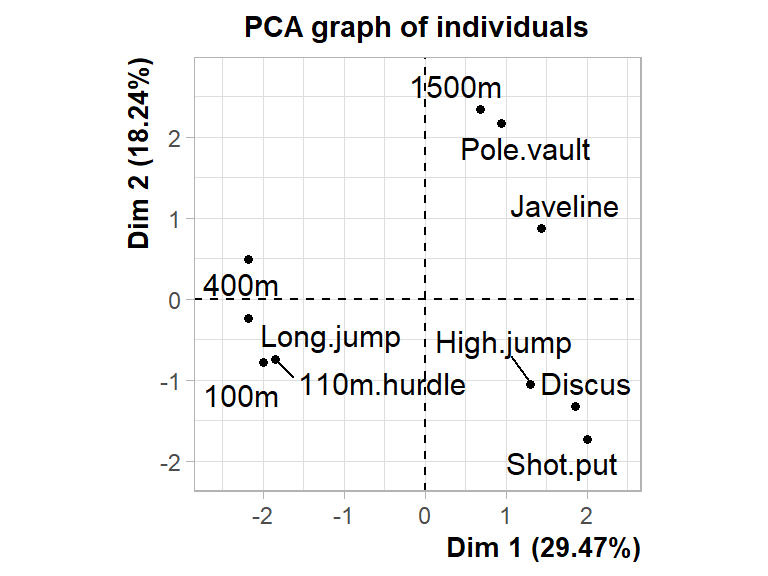

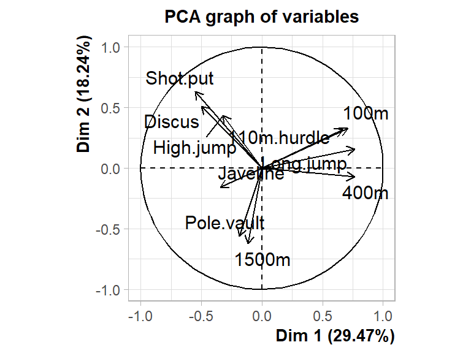

Avec la PCA sur la matrice des distances entre les variables du jeu de données (interprétées comme des individus), on peut voir qu’il y a 3 clusters distincts de variables. On peut réaliser une classification ascendante hierarchique (HCPC) à partir afin de séparer les variables en 3 clusters.

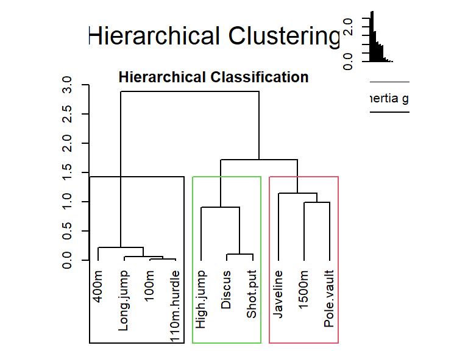

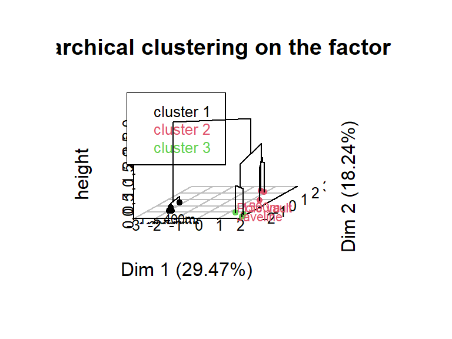

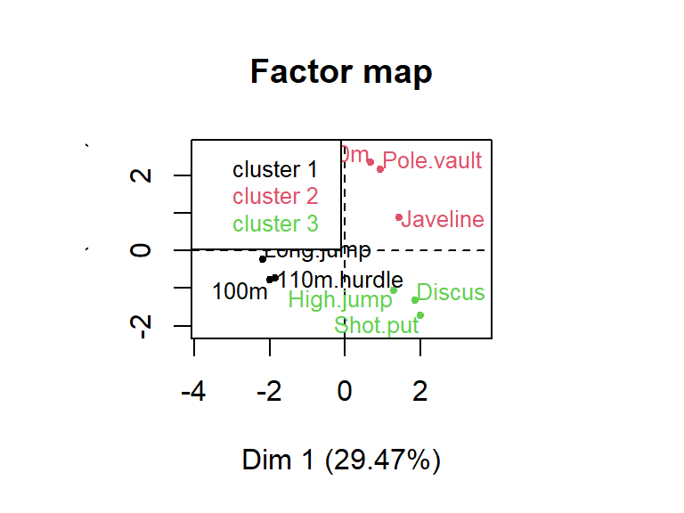

```
## **Results for the Hierarchical Clustering on Principal Components**
##    name
## 1  "$data.clust"
## 2  "$desc.var"
## 3  "$desc.var$quanti.var"
## 4  "$desc.var$quanti"
## 5  "$desc.axes"
## 6  "$desc.axes$quanti.var"
## 7  "$desc.axes$quanti"
## 8  "$desc.ind"
## 9  "$desc.ind$para"
## 10 "$desc.ind$dist"
## 11 "$call"
## 12 "$call$t"
##    description
## 1  "dataset with the cluster of the individuals"
## 2  "description of the clusters by the variables"
## 3  "description of the cluster var. by the continuous var."
## 4  "description of the clusters by the continuous var."
## 5  "description of the clusters by the dimensions"
## 6  "description of the cluster var. by the axes"
## 7  "description of the clusters by the axes"
## 8  "description of the clusters by the individuals"
## 9  "parangons of each clusters"
## 10 "specific individuals"
## 11 "summary statistics"
## 12 "description of the tree"
```

```r
HCPC(res.pca, nb.clust = 3)
```

Les clusters identifiés sont : - 400 m, long jump, 110 m hurdle [110 m haies], 100 m - high jump [saut en hauteur], discus [lancer de disque], shot put [lancer de poids] - 1500 m, pole vault [saut à la perche], javeline [lancer de javelot]

Interprétation des clusters : Les clusters regroupent des variables (épreuves de décathlon) qui se ressemblent, c’est-à-dire pour lesquelles les mêmes individus obtiennent des résultats similaires. Les individus réussissent similairement sur des épreuves similaires pour leur profil sportif, ce qui permet de regrouper les épreuves ensemble par similarité entre elles.

Le cluster 1 regroupe les épreuves de 400 m, saut en longueur, 100 m et 110 m haies. Ces épreuves sont des épreuves de vitesse et ce qui peuvent les rassembler ce sont qu’elles sont bien réussies par des sportifs vifs, impulsifs, ce sont des épreuves de vitesse / explosivité, car elles requièrent une vitesse explosive et une puissance anaérobie.

# 3 Seance 2

En classification, l’objectif est de regrouper des individus (ou objets) présentant des caractéristiques similaires selon certaines variables.

## 3.1 Stratégies de classification

Il existe deux grandes stratégies :

- **Méthode divisive**  
  Approche descendante : on travaille sur les objets et on divise progressivement l’ensemble en sous-groupes.
- **Méthode agrégative**  
  Approche ascendante : on part d’objets isolés et on regroupe progressivement les individus en classes jusqu’à obtenir une partition finale, en regroupant les objets en classes puis les classes entre elles.

## 3.2 Partition

Une **partition** est un découpage complet d’un ensemble d’individus en sous-ensembles disjoints : - Aucun individu n’appartient à deux classes à la fois. - L’union de toutes les classes reconstitue l’ensemble initial.

Dans une **partition floue**, un individu peut appartenir partiellement à plusieurs classes, via des **probabilités d’appartenance**.  
Cela conduit à des approches dites probabilités, basées sur la modélisation de variables aléatoires.

### 3.2.1 Classification hiérarchique ascendante (CAH)

La classification hiérarchique ascendante (CAH) est une méthode agrégative, où on part de n classes (chaque individu seul), on fusionne à chaque étape les classes les plus proches et on obtient un dendrogramme (ou arbre hiérarchique) qui montre les niveaux de regroupement.

Cette méthode est adaptée aux variables quantitatives (une variable correspond à une dimension) et aux variables qualitatives (une modalité correspond à une dimension).

Dans les méthodes hiérarchiques, on construit différents niveau de partition puis on choisit a posteriori selon des critères définis le nombre de clusters à retenir.

En CAH, la méthode est la suivante :

- (Construction d’un plan ou espace dans lequel les objets à classifier se trouvent)
- Choix de la mesure de distance (euclidienne, … )
- Choix du critère aggrégatif entre les groupes
- Mise en oeuvre de la méthode, calculs des distances entre les objets, à chaque étape, les objets les plus proches (plus faible distance les séparant) sont regroupés dans un groupe. Pour aggréger des groupes, on se base sur le critère d’agrégation.
- Construction du dendogramme
- Choix a posteriori de la variable latente, de classe.

Voici un schéma de ce processus. La distance est une distance euclidienne et le critère d’aggrégation est un critère de distance moyenne (distance des centres de gravité).

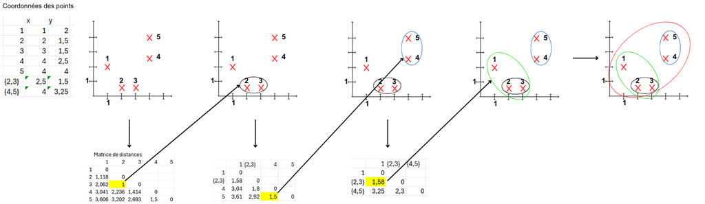

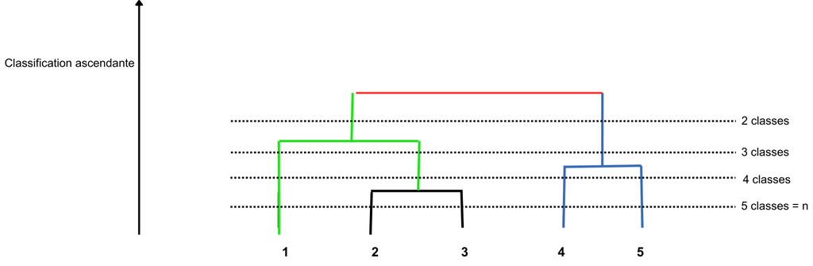

### 3.2.2 Partitionnement direct

Le partitionnement direct consiste à **diviser un ensemble d’individus en un nombre fixe de classes**, sans construction hiérarchique (contrairement à la CAH).

La particularité de ces méthodes est que le nombre de classes doit être déterminé à l’avance. On ne construit pas progressivement les regroupements. On part d’une hypothèse de départ (“je veux former k groupes”) et l’algorithme cherche la meilleure façon de séparer les individus en k classes.

L’objectif est de répartir les individus de sorte que :

- Les individus d’une même classe soient aussi proche que possible les uns des autres, autrement dit on cherche à minimiser la variabilité intra-classe.
- Les classes entre elles soient aussi éloignés que possible, autrement dit on cherche à maximiser la variabilité inter-classe.

Le processus : - On commence par choisir k centres de classes. Ces centres sont souvent choisis au hasard parmi les individus. Chaque centre représente le centre de gravité d’une classe, c’est-à-dire un point moyen dans l’espace des variables.

- Chaque individu est affecté à la classe dont le centre est le plus proche selon une mesure de distance.
- Une fois tous les individus affectés à une classe, on recalcule le centre de chaque classe, appelé centre de classe virtuel.
- Après le recalcul, certains individus peuvent se retrouver plus proches d’un autre centre. On les affecte alors à la nouvelle classe la plus proche.

On répète ces deux étapes (recalcul des centres et réaffectation), jusqu’à convergence de l’algorithme où la variabilité intra-classe est minimale et la variabilité inter-classe est maximale.

Un exemple est le k-means, où le calcul des centres de gravité se fait au fur et à mesure de l’affectation de chaque individu.

### 3.2.3 Méthodes mixtes

Les méthodes mixtes combinent le partitionnement direct et la CAH. On réalise un partitionnement direct pour obtenir des centres de classes initiaux et on applique une CAH sur ces centres. Cela permet de réduire le nombre d’individus pour réaliser la CAH.

## 3.3 TD : étude appliqué sur le saumon

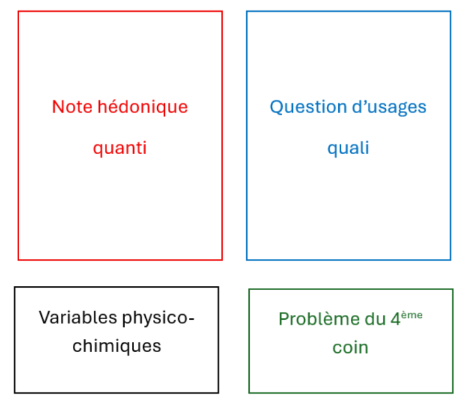

On dispose d’un jeu de donné structuré en 3 blocs :

- Un bloc « rouge » : avec les individus en lignes et les saumons en colonnes. Ce bloc contient les notes hédoniques attribuées par chaque individu à chaque saumon.
- Un bloc « bleu » : placé à droite du bloc rouge, il comporte les mêmes individus en lignes, mais avec des variables qualitatives en colonnes. Ce bloc décrit les habitudes de consommation du saumon pour chaque individu.
- Un bloc « noir » : situé sous le bloc rouge, il présente les saumons en colonnes et les paramètre physico-chimiques (inconnus des individus) en lignes (ex : taux de sel, etc)

### 3.3.1 Problématique

**Problématique : le “problème du 4ème coin”.** L’objectif est de comprendre comment les préférences hédoniques des consommateurs s’articulent avec leurs habitudes de consommation et les caractéristiques physico-chimiques des produits. Autrement dit, de vérifier si ce qu’expriment les individus à propos de leur consommation en saumon est exacte ou non.

Pour cela, on va :

- Classer les consommateurs selon leurs préférences hédoniques.
- Caractériser les classes obtenues à l’aide des variables d’usage (issues du bloc bleu) pour mieux comprendre la structure hédonique.
- Evaluer l’apport des données physico-chimiques (bloc noir) dans la compréhension des préférences hédoniques par les variables d’usage.

Cette approche permet notamment de vérifier si les déclarations des individus concernant leur consommation de saumon sont cohérentes avec la réalité. Par exemple, si un groupe d’individus affirment préférer les saumons salés (variable Not.to.salty_No du bloc bleu), on devrait observer une corrélation avec le paramètre « salt » du bloc noir. Cela confirmerait la fiabilité de leurs descriptions sensorielles et la pertinence de leurs jugements lors de la notation des produits.

### 3.3.2 Méthode

Nous allons procéder en 3 étapes :

**Etape 1 :** Analyse du bloc rouge (individus x saumons) L’objectif : regrouper les individus selon leurs préférences hédoniques vis-à-vis des différents saumons.

- Réalisation d’un ACP (PCA()) sur les variables quantitatives du bloc rouge
- Suivie d’une classification hiérarchique (HCPC()) pour identifier des clusters d’individus aux comportements similaires.

**Etape 2 :** Interprétation à l’aide du bloc bleu (individus x conditions de consommation)

L’objectif : interpréter les classes obtenues à l’étape précédente en fonction des variables qualitatives décrivant les habitudes ou préférences de consommation. Ceci doit permettre de comprendre les différences de notes entre individus et d’identifier les descripteurs discriminants pour chaque groupe.

Méthode :

- Réaliser une ACP avec les variables quantitatives du bloc rouge comme actives et les variables catégorielles du bloc bleu comme variables qualitatives supplémentaires.
- Utiliser la fonction desc.var() pour extraire les variables les plus significatives.

**Etape 3 :** Validation à l’aide du bloc noir (paramètres physico-chimiques x saumons)

Objectif : confirmer la cohérence des justifications données par les individus en les confrontant aux mesures physico-chimiques réelles. Cette étape vise à évaluer la pertinence du panel en matière de jugement sensoriel.

Chaque paramètre physico-chimique est considéré comme un individu supplémentaire fictif, très sensible au critère correspondant.

Ainsi, un individu “Salt” notera favorablement les saumons les plus salés, il se positionne donc dans l’espace factoriel près des individus ayant eux aussi attribué de bonnes notes à ces produits. Cela nous permettra de rendre légitime ou non la note des vrais individus, conditionnellement aux appréciations de consommation de chaque vrai individu (bloc bleu).

Méthode :

- Réaliser une ACP avec les variables quantitatives du bloc rouge comme actives, les variables catégorielles du bloc bleu comme supplémentaires et les paramètres du bloc noir comme individus supplémentaires
- Terminer par une HCPC() pour observer à quelles classes se rattachent les individus

### 3.3.3 Mise en oeuvre

Chargement des données et des packages

```r
library(factoextra)
library(FactoMineR)

### Import et traitement des données
dta_saumon<-read.table("data/saumon.csv",
                       stringsAsFactors = TRUE,
                       dec=",",
                       sep=";",
                       header = TRUE)
dta_saumon_N<-dta_saumon[c(1064:1088),c(1,3:32)]
dta_saumon_RB<-dta_saumon[c(1:1063),]
dta_saumon_R<-dta_saumon[,c(3:32)]

dta_saumon_R<-as.matrix(dta_saumon_R)
```

#### 3.3.3.1 Etape 1 : PCA sur dta_saumon_R

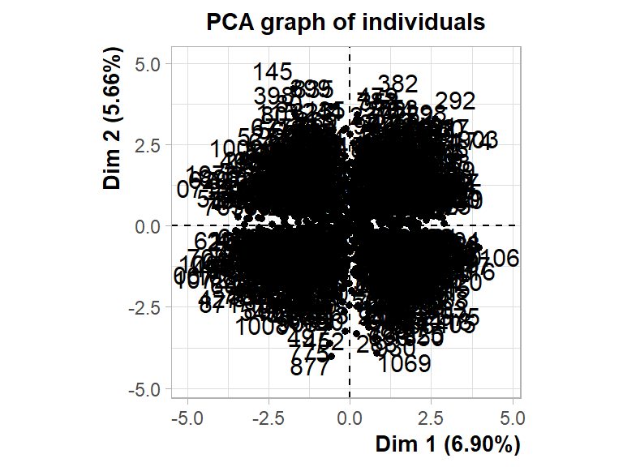

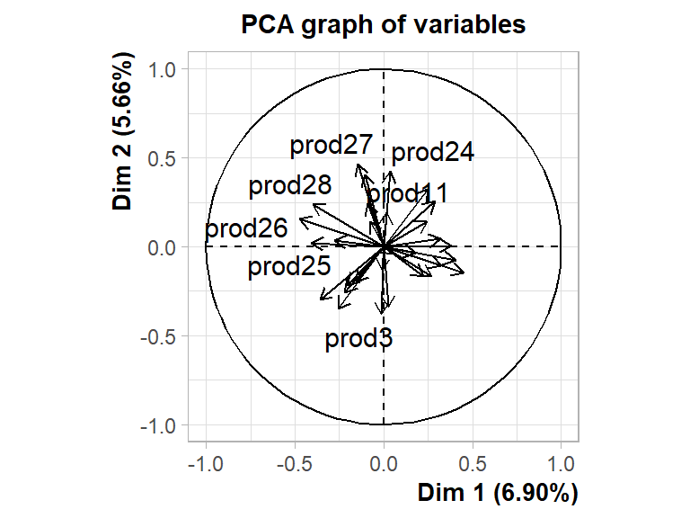

```r
res.pca.1<-PCA(dta_saumon_R,graph = TRUE, ncp = 30)
```

```r
# res.pca.1$eig
res.HCPC1 <- HCPC(res.pca.1, nb.clust = -1) # avec nb.clust = -1 : choix optimal du nombre de clusters
```

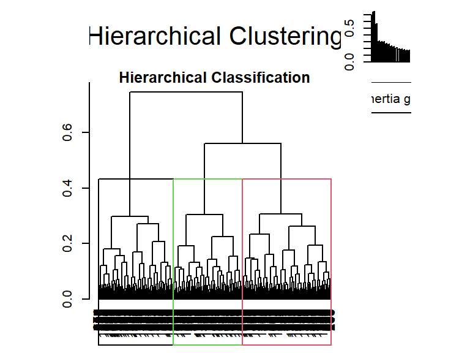

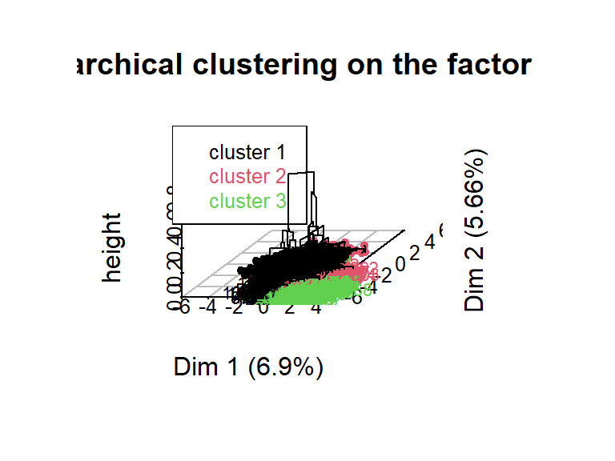

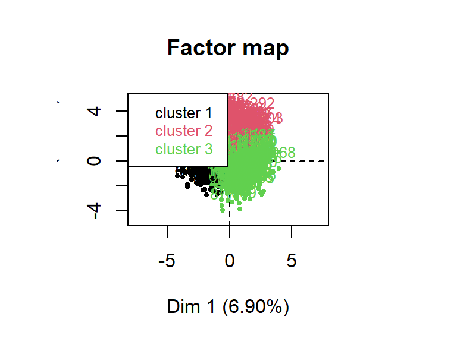

Objets de res HCPC :

```r
# 1 - "data.clust"
res.HCPC1$data.clust
```

|  | prod1 | prod2 | prod3 | prod4 | prod5 | prod6 | prod7 | prod8 | prod9 | prod10 | prod11 | prod12 | prod13 | prod14 | prod15 | prod16 | prod17 | prod18 | prod19 | prod20 | prod21 | prod22 | prod23 | prod24 | prod25 | prod26 | prod27 | prod28 | prod29 | … |
| --- | --- | --- | --- | --- | --- | --- | --- | --- | --- | --- | --- | --- | --- | --- | --- | --- | --- | --- | --- | --- | --- | --- | --- | --- | --- | --- | --- | --- | --- | --- |
| 1 | 0.5433000 | 0.54330000 | -0.0187000 | 0.5433000 | 0.5433000 | -0.0187000 | 1.1054000 | -0.58080000 | 0.5433000 | -0.5808000 | -0.018700000 | -2.82900000 | 0.5433000 | -1.704900000 | -1.70490000 | -1.1428000 | 1.6674000 | -0.0187000 | 0.54330000 | -0.5808000 | 1.1054000 | 1.6674000 | -0.5808000 | 0.5433000 | 0.5433000 | -0.018700000 | -1.1428000 | -0.58080000 | 1.10540000 | … |
| 2 | 0.4685000 | -0.31230000 | 0.4685000 | 0.4685000 | 1.2494000 | -1.0932000 | -0.3123000 | 1.24940000 | 0.4685000 | -0.3123000 | 1.249400000 | 0.46850000 | -0.3123000 | 1.249400000 | -2.65500000 | 1.2494000 | -1.8741000 | -1.0932000 | 0.46850000 | -1.0932000 | 0.4685000 | 1.2494000 | -1.0932000 | -1.0932000 | 0.4685000 | -0.312300000 | -0.3123000 | -0.31230000 | 1.24940000 | … |
| 3 | 0.4354000 | 1.36830000 | -0.9641000 | 0.4354000 | 1.3683000 | -0.4976000 | 0.4354000 | -0.49760000 | 0.4354000 | -0.9641000 | -0.964100000 | -0.03110000 | -0.0311000 | -0.964100000 | 0.90190000 | -2.3635000 | 0.4354000 | -1.8970000 | 0.43540000 | 0.9019000 | 0.4354000 | -1.4305000 | 0.4354000 | 0.9019000 | 1.3683000 | -0.497600000 | -0.0311000 | 1.36830000 | 0.90190000 | … |
| 4 | 1.6920000 | 1.69200000 | 0.6004000 | 1.1462000 | 0.6004000 | -0.4912000 | -1.0371000 | -1.58290000 | 0.6004000 | 0.0546000 | -0.491200000 | 0.05460000 | -1.5829000 | -1.037100000 | 0.60040000 | 0.0546000 | -1.0371000 | -1.5829000 | -1.03710000 | -0.4912000 | 1.6920000 | 0.0546000 | 1.1462000 | 0.6004000 | -0.4912000 | 0.054600000 | -1.0371000 | -0.49120000 | 0.05460000 | … |
| 5 | 0.6167000 | -0.20560000 | 0.2056000 | -0.6167000 | -1.4389000 | 0.6167000 | 0.6167000 | 0.20560000 | 1.0278000 | 0.6167000 | -0.616700000 | 0.61670000 | 1.0278000 | 0.205600000 | -1.85000000 | -0.6167000 | 0.6167000 | 0.6167000 | 1.02780000 | 1.4389000 | -1.4389000 | 1.0278000 | 1.4389000 | -1.8500000 | -1.0278000 | -0.616700000 | -1.0278000 | -1.85000000 | 0.61670000 | … |
| 6 | -0.0165000 | 0.97140000 | -1.9922000 | 0.9714000 | -1.0043000 | 0.9714000 | -0.5104000 | 1.46530000 | 0.4775000 | -0.5104000 | 1.465300000 | 0.47750000 | 0.4775000 | 0.971400000 | 0.47750000 | -0.0165000 | 0.4775000 | -1.9922000 | -1.49830000 | -0.5104000 | -0.5104000 | -0.5104000 | 1.4653000 | -1.0043000 | -0.0165000 | -1.004300000 | -0.0165000 | -1.49830000 | 0.97140000 | … |
| 7 | 0.5557000 | 0.55570000 | -0.0617000 | -0.0617000 | -0.6792000 | 1.7905000 | -0.0617000 | -1.29660000 | -0.0617000 | -0.6792000 | 1.173100000 | -1.29660000 | -1.2966000 | 0.555700000 | 1.17310000 | -1.9140000 | -0.0617000 | -1.2966000 | -0.67920000 | 1.1731000 | 1.7905000 | 0.5557000 | -0.0617000 | -0.6792000 | -1.2966000 | -0.679200000 | -0.0617000 | 0.55570000 | 0.55570000 | … |
| 8 | -0.8881000 | -1.45490000 | -0.3212000 | 1.3793000 | 1.9462000 | 0.2456000 | -0.8881000 | 0.81250000 | 0.8125000 | 0.2456000 | 0.812500000 | 1.37930000 | 0.2456000 | -0.321200000 | -0.88810000 | -1.4549000 | -0.3212000 | -1.4549000 | 0.81250000 | 0.8125000 | -1.4549000 | 0.2456000 | 0.8125000 | 0.8125000 | -0.8881000 | 0.812500000 | 0.8125000 | -1.45490000 | -1.45490000 | … |
| 9 | -0.1374000 | -0.96150000 | 1.5110000 | -0.1374000 | 0.6868000 | 0.6868000 | -0.1374000 | -0.13740000 | 0.6868000 | 0.6868000 | -0.137400000 | -0.96150000 | -0.1374000 | -0.961500000 | -0.96150000 | -0.9615000 | 0.6868000 | 0.6868000 | -1.78570000 | -0.9615000 | -0.9615000 | -0.9615000 | -0.1374000 | 1.5110000 | 1.5110000 | 2.335100000 | 0.6868000 | -1.78570000 | -0.13740000 | … |
| 10 | 0.8712000 | -1.42140000 | -1.8799000 | -0.5044000 | 0.8712000 | 1.3297000 | -0.0459000 | -0.50440000 | -0.0459000 | -0.0459000 | 1.329700000 | 0.87120000 | 1.3297000 | -0.962900000 | 0.87120000 | 0.4127000 | -1.4214000 | 0.4127000 | -0.96290000 | -0.9629000 | -0.5044000 | 0.4127000 | 1.3297000 | 0.4127000 | -0.9629000 | 0.412700000 | 0.8712000 | 1.32970000 | -1.87990000 | … |

[output cut: 1078 more lines]

```r
# data frame individu actifs et de toutes les variables actives, illustratives, ainsi que de la variable de classe ("clust"=> la dernière variable)

# 2 - "desc.var"
# description des classes (clusters)
res.HCPC1$desc.var$category # v test pour les clusters (test de surreprésentation de la modalité) => modalités caractérisant les groupes
```

```r
 ### rappels
 ## CLA/MOD : % d'individus qui prennent cette modalité pour cette variable et qui sont dans CE CLUSTER
 ## MOD/CLA : % d'individus DE CE CLUST QUI ONT PRIS cette modalité pour cette variable
 ## Global  : % d'individus en global qui prennent cette modalité pour cette variable
 ## p value : proba associé d'observer sous H0 une valeur de v test au moins aussi élevée que celle observée réellement
 ## v. test : valeur de la stat de test

# 3 - "desc.axes"
res.HCPC1$desc.axes
```

```
##
## Link between the cluster variable and the quantitative variables
## ================================================================
##               Eta2       P-value
## Dim.1  0.617344948 4.710235e-227
## Dim.2  0.448195136 8.291766e-141
## Dim.3  0.094017098  5.465136e-24
## Dim.5  0.016369037  1.292599e-04
## Dim.10 0.007969649  1.302538e-02
## Dim.26 0.005944421  3.938101e-02
##
## Description of each cluster by quantitative variables
## =====================================================
## $`1`
##            v.test Mean in category  Overall mean sd in category Overall sd
## Dim.13  -2.145057      -0.08872994 -1.169073e-16      1.0075737   1.003172
## Dim.3   -3.982587      -0.20624134 -2.346070e-16      1.2210587   1.255899
## Dim.2   -4.882808      -0.26225679 -3.664922e-17      0.9857257   1.302570
## Dim.1  -25.139353      -1.49100280  9.362405e-17      0.8368241   1.438363
##              p.value
## Dim.13  3.194832e-02
## Dim.3   6.816924e-05
## Dim.2   1.045857e-06
## Dim.1  1.847780e-139
##
## $`2`
##          v.test Mean in category  Overall mean sd in category Overall sd
## Dim.2 21.024462        1.2036259 -3.664922e-17      0.9530078   1.302570
## Dim.3 10.027171        0.5534755 -2.346070e-16      1.1782745   1.255899
## Dim.1  7.376406        0.4663143  9.362405e-17      0.9842050   1.438363
## Dim.6 -2.366706       -0.1190403  7.081435e-17      1.1338903   1.144417
## Dim.5 -4.199049       -0.2147275 -2.778603e-16      1.1265741   1.163513
##            p.value
## Dim.2 3.918098e-98
## Dim.3 1.157870e-23
## Dim.1 1.626193e-13
## Dim.6 1.794717e-02
## Dim.5 2.680387e-05
##
## $`3`
##            v.test Mean in category  Overall mean sd in category Overall sd
## Dim.1   18.238328       1.14334299  9.362405e-17      0.8455900  1.4383629
## Dim.26   2.534956       0.09356636 -1.245417e-16      0.8914330  0.8468884
## Dim.5    2.368750       0.12011953 -2.778603e-16      1.1852461  1.1635131
## Dim.21   2.352031       0.09320825  9.328284e-17      0.9427737  0.9092604
## Dim.9   -1.973254      -0.08960118 -2.502004e-16      1.0650676  1.0418561
## Dim.10  -2.881723      -0.13044149 -6.871530e-17      1.0004744  1.0385814
## Dim.3   -5.943226      -0.32531185 -2.346070e-16      1.1842640  1.2558986
## Dim.2  -15.991714      -0.90786080 -3.664922e-17      0.9622041  1.3025704
##             p.value
## Dim.1  2.561731e-74
## Dim.26 1.124614e-02
## Dim.5  1.784829e-02
## Dim.21 1.867122e-02
## Dim.9  4.846664e-02
## Dim.10 3.955078e-03
## Dim.3  2.794661e-09
## Dim.2  1.459584e-57
```

```r
# link between the cluster variable and the quantitative variables
# Description of each cluster by quantitative variables


# 4 - "desc.ind"
res.HCPC1$desc.ind$para # individus les plus proches des centres des classes
```

```
## Cluster: 1
##      770      666      766      664      702
## 4.469130 4.613744 4.667030 4.716111 4.766509
## ------------------------------------------------------------
## Cluster: 2
##     1003      292       91      815      382
## 1.443863 4.323835 4.336060 4.343096 4.347783
## ------------------------------------------------------------
## Cluster: 3
##      848       17      645     1068       57
## 4.500872 4.523278 4.562772 4.571646 4.575069
```

```r
res.HCPC1$desc.ind$dist # individus les plus éloignés des centres des autres classes
```

```
## Cluster: 1
##     1072      871     1075     1071      427
## 6.779814 6.565614 6.515870 6.512296 6.496780
## ------------------------------------------------------------
## Cluster: 2
##      198     1088      973      619      725
## 6.143636 6.130168 6.117107 6.110993 6.036744
## ------------------------------------------------------------
## Cluster: 3
##      534       14      468      998      103
## 6.321963 6.320040 6.289498 6.259481 6.252432
```

Ainsi, on en déduit que :

On peut aussi savoir les produits qui séparent le plus les groupes entre eux : il s’agit des saumons **16, 26, 10 et 29**.

#### 3.3.3.2 Etape 2 : PCA sur dta_saumon_R + var illus B

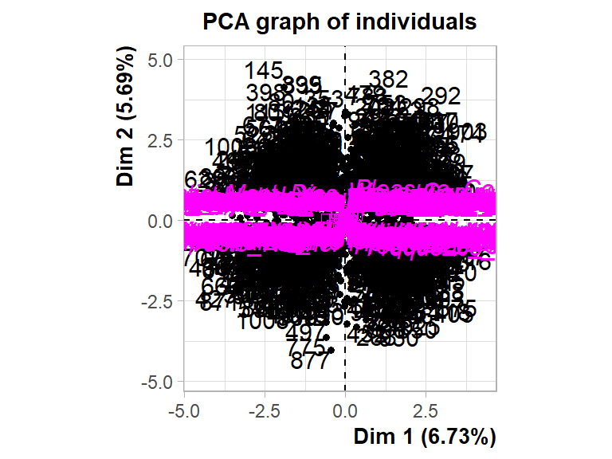

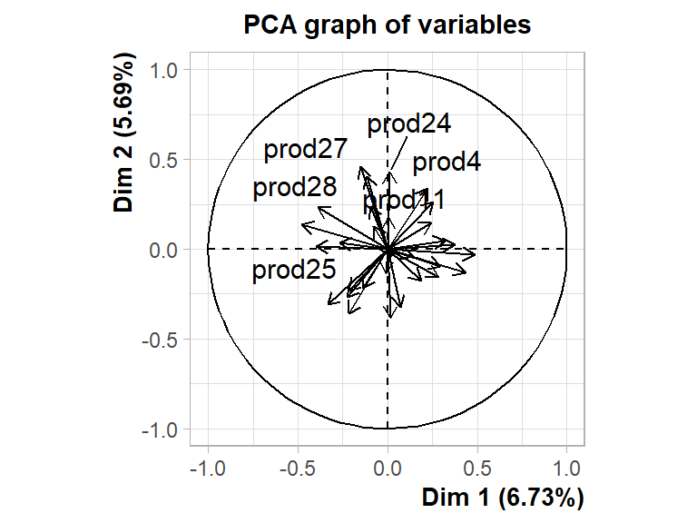

```r
res.pca.2<-PCA(dta_saumon_RB [c(-1,-2)],
               quali.sup = c(31:98),
               graph = TRUE)
```

```r
res.HCPC2 <- HCPC(res.pca.2, nb.clust = -1)
```

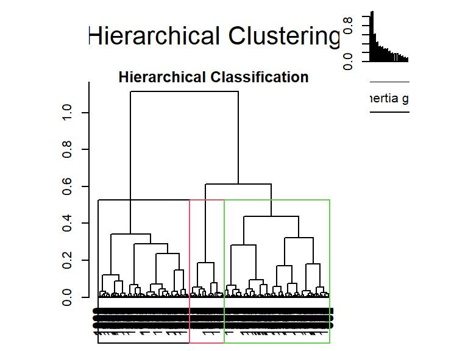

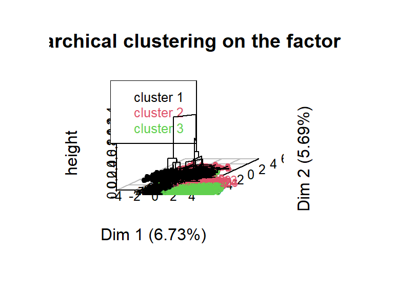

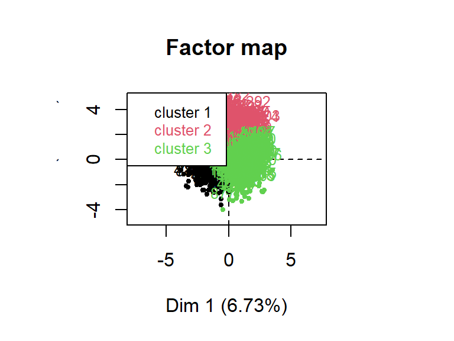

```r
res.HCPC2$desc.var
```

```
##
## Link between the cluster variable and the categorical variables (chi-square test)
## =================================================================================
##                           p.value df
## Not.too.salty        3.994099e-05  2
## Appetising           8.494705e-03  2
## Firm.texture         1.658330e-02  2
## Characteristic.taste 2.227731e-02  2
## Wild                 2.922109e-02  2
## Not.expensive        3.191417e-02  8
## Glossiness           3.678832e-02  2
## Healthy              3.828854e-02  8
##
## Description of each cluster by the categories
## =============================================
## $`1`
##                                          Cla/Mod   Mod/Cla    Global
## Not.too.salty=Not.too.salty_Yes         41.17647 43.048128 36.782690
## Firm.texture=Firm.texture_No            37.37981 83.155080 78.269050
## Glossiness=Glossiness_Yes               41.11842 33.422460 28.598307
## Wild=Wild_Yes                           42.65403 24.064171 19.849483
## Horseradish=Horseradish_Yes             42.77778 20.588235 16.933208
## Smooth.texture=Smooth.texture_Yes       43.31210 18.181818 14.769520
## Not.expensive=Not.expensive_Comp. Agree 51.16279  5.882353  4.045155
## Evening.snack=Evening.snack_Yes         39.37824 40.641711 36.312324
## Main=Main_No                            36.80297 79.411765 75.917215
## Main=Main_Yes                           30.07812 20.588235 24.082785
## Not.expensive=Not.expensive_Comp. Disa. 27.20588  9.893048 12.793979
## Evening.snack=Evening.snack_No          32.79173 59.358289 63.687676
## Smooth.texture=Smooth.texture_No        33.77483 81.818182 85.230480
## Horseradish=Horseradish_No              33.63533 79.411765 83.066792
## Wild=Wild_No                            33.33333 75.935829 80.150517
## Glossiness=Glossiness_No                32.80632 66.577540 71.401693
## Firm.texture=Firm.texture_Yes           27.27273 16.844920 21.730950
## Not.too.salty=Not.too.salty_No          31.69643 56.951872 63.217310
##                                             p.value    v.test
## Not.too.salty=Not.too.salty_Yes         0.001917170  3.102772
## Firm.texture=Firm.texture_No            0.004047093  2.874468
## Glossiness=Glossiness_Yes               0.010954382  2.544151
## Wild=Wild_Yes                           0.012114617  2.508788
```

[output cut: 240 more lines]

```
## prod30 7.564437e-07
## prod12 4.139156e-04
## prod14 2.323311e-02
## prod6  4.496407e-02
## prod1  3.437883e-02
## prod2  4.435964e-03
## prod18 3.004622e-03
## prod24 5.037264e-06
## prod21 2.850070e-08
## prod13 1.994962e-09
## prod11 1.268007e-13
## prod25 4.226371e-16
## prod27 7.380510e-28
## prod28 7.604511e-30
## prod26 5.133585e-36
```

#### 3.3.3.3 Etape 3 : PCA sur dta_saumon_R + var illus B + ind illus N

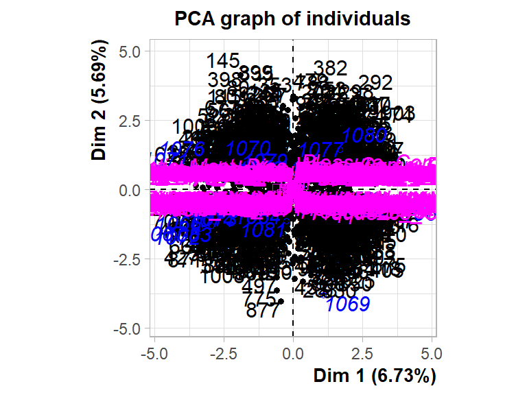

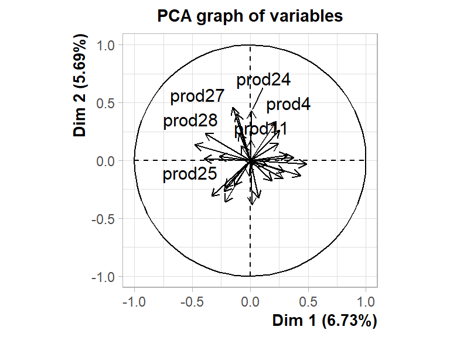

```r
res.pca.3<-PCA(dta_saumon[c(-1,-2)],
               quali.sup = c(31:98),
               ind.sup = 1064:1088,
               graph = TRUE)
```

```r
res.HCPC.3<-HCPC(res.pca.3,nb.clust=-1)
```

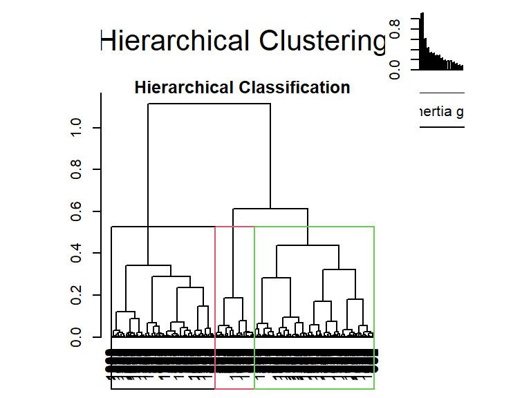

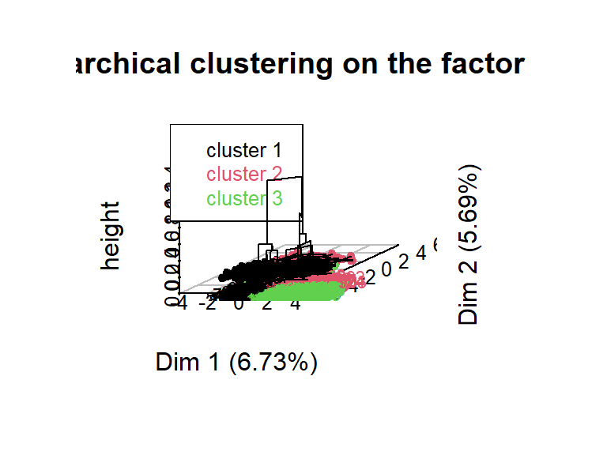

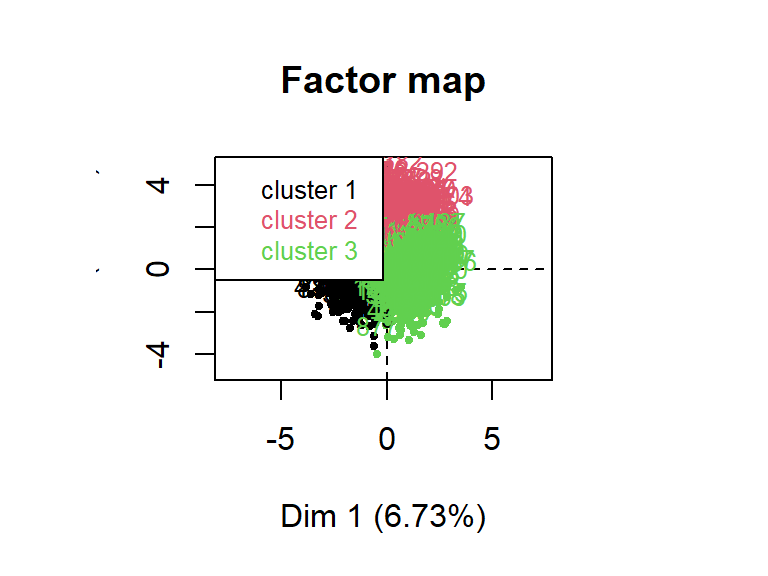

```r
res.HCPC.3$desc.var
```

```
##
## Link between the cluster variable and the categorical variables (chi-square test)
## =================================================================================
##                           p.value df
## Not.too.salty        3.994099e-05  2
## Appetising           8.494705e-03  2
## Firm.texture         1.658330e-02  2
## Characteristic.taste 2.227731e-02  2
## Wild                 2.922109e-02  2
## Not.expensive        3.191417e-02  8
## Glossiness           3.678832e-02  2
## Healthy              3.828854e-02  8
##
## Description of each cluster by the categories
## =============================================
## $`1`
##                                          Cla/Mod   Mod/Cla    Global
## Not.too.salty=Not.too.salty_Yes         41.17647 43.048128 36.782690
## Firm.texture=Firm.texture_No            37.37981 83.155080 78.269050
## Glossiness=Glossiness_Yes               41.11842 33.422460 28.598307
## Wild=Wild_Yes                           42.65403 24.064171 19.849483
## Horseradish=Horseradish_Yes             42.77778 20.588235 16.933208
## Smooth.texture=Smooth.texture_Yes       43.31210 18.181818 14.769520
## Not.expensive=Not.expensive_Comp. Agree 51.16279  5.882353  4.045155
## Evening.snack=Evening.snack_Yes         39.37824 40.641711 36.312324
## Main=Main_No                            36.80297 79.411765 75.917215
## Main=Main_Yes                           30.07812 20.588235 24.082785
## Not.expensive=Not.expensive_Comp. Disa. 27.20588  9.893048 12.793979
## Evening.snack=Evening.snack_No          32.79173 59.358289 63.687676
## Smooth.texture=Smooth.texture_No        33.77483 81.818182 85.230480
## Horseradish=Horseradish_No              33.63533 79.411765 83.066792
## Wild=Wild_No                            33.33333 75.935829 80.150517
## Glossiness=Glossiness_No                32.80632 66.577540 71.401693
## Firm.texture=Firm.texture_Yes           27.27273 16.844920 21.730950
## Not.too.salty=Not.too.salty_No          31.69643 56.951872 63.217310
##                                             p.value    v.test
## Not.too.salty=Not.too.salty_Yes         0.001917170  3.102772
## Firm.texture=Firm.texture_No            0.004047093  2.874468
## Glossiness=Glossiness_Yes               0.010954382  2.544151
## Wild=Wild_Yes                           0.012114617  2.508788
```

[output cut: 240 more lines]

```
## prod30 7.570499e-07
## prod12 4.139772e-04
## prod14 2.322499e-02
## prod6  4.493668e-02
## prod1  3.438518e-02
## prod2  4.435122e-03
## prod18 3.003117e-03
## prod24 5.037596e-06
## prod21 2.847018e-08
## prod13 1.995877e-09
## prod11 1.267976e-13
## prod25 4.219113e-16
## prod27 7.377113e-28
## prod28 7.587026e-30
## prod26 5.128224e-36
```

### 3.3.4 Graphique

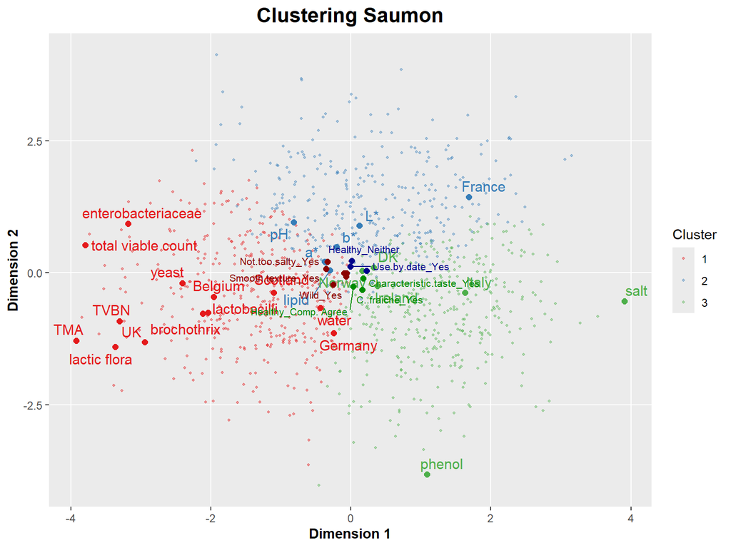

```r
library(factoextra)
library(ggplot2)
library(ggrepel)
library(dplyr)

###############################

coord_ind <- res.pca.3$ind$coord
clust     <- res.HCPC.3$data.clust$clust
ind_sup   <- as.data.frame(res.pca.3$ind.sup$coord)
rownames(ind_sup) <- dta_saumon_N$IKIDEN

combined <- cbind(coord_ind,clust)

# ajouter le bleu : les habitudes de consommation
quali_sup <- as.data.frame(res.pca.3$quali.sup$coord)

# conserver que ceux qui sont intéressants
quali_sup <- quali_sup[c(236,226,188,167,224,63,
                         29,203,28,
                         233,128,25),]

col_ind_sup <- c("#E41A1C", "#377EB8", "#E41A1C", "#E41A1C",
             "#4DAF4A", "#4DAF4A", "#377EB8", "#E41A1C",
             "#E41A1C", "#E41A1C", "#E41A1C", "#E41A1C",
             "#E41A1C", "#377EB8", "#377EB8","#377EB8",
             "#377EB8", "#E41A1C", "#4DAF4A", "#E41A1C",
             "#4DAF4A", "#E41A1C", "#4DAF4A", "#E41A1C",
             "#4DAF4A")

col_quali_sup <- c(rep("red4",6), rep("blue4",3),rep("green4",3))

p1 <- combined %>%
  ggplot() +
  aes(x = Dim.1, y = Dim.2, color = factor(clust)) +
  geom_point(size = 0.8, alpha = 0.4) +
  scale_color_manual(
    values = c(
      "1" = "#E41A1C",
      "2" = "#377EB8",
      "3" = "#4DAF4A"
    ),
    name = "Cluster"
  ) +

  # Points supplémentaires individus
  geom_point(data = ind_sup,
             aes(x = Dim.1, y = Dim.2),
             color = col_ind_sup,
             size = 2,
             shape = 16) +

  geom_text_repel(data = ind_sup,
                  aes(label = row.names(ind_sup)),
                  color = col_ind_sup,
                  size = 4) +

  # Points supplémentaires qualitatifs
  geom_point(data = quali_sup,
             aes(x = Dim.1, y = Dim.2),
             color = col_quali_sup,
             size = 2,
             shape = 16) +

  geom_text_repel(data = quali_sup,
                  aes(label = row.names(quali_sup)),
                  color = col_quali_sup,
                  size = 2.8,
                  max.overlaps = 16) +

  labs(
    title = "Clustering Saumon",
    x = "Dimension 1",
    y = "Dimension 2"
  ) +

  theme(
    legend.position = "right",
    plot.title = element_text(face = "bold", size = 16, hjust = 0.5),
    axis.title = element_text(face = "bold"),
    panel.grid.minor = element_blank()
  )

p1
```

### 3.3.5 Interprétations

L’analyse hiérarchique sur composantes principales (HCPC) réalisée sur le jeu de données dta_saumon a permis d’identifier trois groupes distincts de consommateurs selon leurs perceptions sensorielles, leurs jugements qualitatifs et leurs préférences à l’égard de différents produits à base de saumon.

Ces classes sont issues du traitement statistique res.HCPC.3$desc.var, qui met en évidence les variables discriminantes et leur poids explicatif (v.test, p-value, moyennes).

1. Description générale des variables discriminantes Les tests du χ² ont montré que plusieurs variables qualitatives sont significativement associées à la variable de cluster. Parmi elles, huit se distinguent particulièrement :

Not.too.salty (p = 3,99×10⁻⁵),

Appetising (p = 8,49×10⁻³),

Firm.texture (p = 1,66×10⁻²),

Characteristic.taste (p = 2,23×10⁻²),

Wild (p = 2,92×10⁻²),

Not.expensive (p = 3,19×10⁻²),

Glossiness (p = 3,67×10⁻²),

Healthy (p = 3,83×10⁻²).

Ces p-values, toutes inférieures à 0,05, indiquent que ces variables contribuent de manière significative à la différenciation entre les groupes de consommateurs. Les axes de segmentation reposent donc à la fois sur la perception sensorielle (salinité, texture, goût), l’image du produit (naturel, sain, sauvage) et la valeur perçue (prix, aspect appétissant).

2. Analyse détaillée des clusters

**Cluster 1 : des consommateurs recherchant un saumon doux, naturel et accessible** Le premier groupe, majoritairement composé d’individus appréciant la douceur du saumon, se distingue nettement par des préférences pour un produit peu salé, à la texture lisse, perçu comme naturel et abordable.

Sur le plan qualitatif, plusieurs catégories sont significativement surreprésentées :

« Not too salty = Yes » (v.test = 3,10 ; p = 0,0019),

« Firm texture = No » (v.test = 2,87 ; p = 0,004),

« Glossiness = Yes » (v.test = 2,54 ; p = 0,011),

« Wild = Yes » (v.test = 2,51 ; p = 0,012),

« Smooth texture = Yes » (v.test = 2,28 ; p = 0,023),

« Not expensive = Agree » (v.test = 2,17 ; p = 0,029).

Ces résultats traduisent une préférence pour un saumon naturel et peu salé, dont l’apparence brillante est jugée fraîche et appétissante. Les consommateurs de ce cluster associent fréquemment le produit à une origine sauvage, gage de qualité et de naturalité, et le perçoivent comme économique. Ils privilégient également une texture souple et lisse, au détriment des chairs trop fermes.

Les données quantitatives confirment cette tendance. Les produits prod25 (v.test = 9,76), prod16 (v.test = 9,51) et prod26 (v.test = 9,44) présentent des moyennes de satisfaction supérieures à la moyenne globale, traduisant un haut niveau d’appréciation pour ces profils. À l’inverse, prod10 (v.test = –12,80) et prod29 (v.test = –10,23) obtiennent des notes nettement inférieures, indiquant un rejet des produits perçus comme trop salés ou trop puissants.

En somme, le premier cluster regroupe des consommateurs qui valorisent un saumon doux, lisse, peu salé et naturel, souvent associé à une consommation simple et abordable. Les p-values extrêmement faibles (< 0,01) et les v.test supérieurs à 9 confirment la stabilité statistique de ce profil.

**Cluster 2 : des consommateurs distants, rationnels et peu impliqués**

Le deuxième cluster se distingue par une attitude plus neutre et distante vis-à-vis du produit. Ces individus semblent peu enthousiasmés par le saumon, mais attentifs aux aspects pratiques et de sécurité alimentaire.

Les variables qualitatives les plus discriminantes sont : « Appetising = No » (v.test = 3,06 ; p = 0,002),

« Healthy = Neither » (v.test = 2,36 ; p = 0,019),

« Use by date = Yes » (v.test = 2,32 ; p = 0,020),

« Supermarket = Yes » (v.test = 2,00 ; p = 0,046).

Ce groupe juge le saumon peu appétissant, et le considère ni sain ni malsain, traduisant un certain désintérêt gustatif. En revanche, ces consommateurs sont plus attentifs à la date limite de consommation et achètent majoritairement en supermarché, ce qui renvoie à un comportement de consommation rationnel et pratique.

Les variables quantitatives associées appuient cette lecture : Les produits prod4 (v.test = 9,39 ; moyenne = 0,617) et prod27 (v.test = 9,09 ; moyenne = 0,538) sont les plus représentatifs de ce groupe, suggérant une préférence pour des textures plus fermes et structurées.

À l’inverse, prod16 (v.test = –10,50) et prod18 (v.test = –5,87) sont nettement sous-notés, ce qui montre un rejet des saumons doux et délicats. Ce cluster correspond donc à des consommateurs pragmatiques, dont la relation au produit est fonctionnelle plutôt que émotionnelle. Ils consomment du saumon sans véritable enthousiasme, mais en respectant des critères de sécurité et de praticité (fraîcheur, date, achat courant). Les v.test élevés (supérieurs à 9 pour certaines variables) et les p-values inférieures à 10⁻²⁰ traduisent une forte cohérence interne.

**Cluster 3 : des amateurs de saumon salé, intense et perçu comme sain**

Le troisième cluster regroupe des consommateurs qui valorisent au contraire un goût puissant et typique, une salinité marquée et une image positive du produit en termes de santé.

Les catégories les plus caractéristiques sont : « Not too salty = No » (v.test = 4,44 ; p = 9,1×10⁻⁶),

« Healthy = Completely agree » (v.test = 2,79 ; p = 0,005),

« Characteristic taste = Yes » (v.test = 2,73 ; p = 0,006),

« Crème fraîche = Yes » (v.test = 2,10 ; p = 0,036).

Ces consommateurs recherchent un goût prononcé, typé et salé, qu’ils associent à une expérience culinaire complète (souvent accompagnée de crème fraîche). Ils considèrent également le saumon comme un aliment sain, ce qui renforce une image de plaisir équilibré.

Les données quantitatives corroborent cette interprétation :

- prod10 (v.test = 10,83), prod29 (v.test = 10,67) et prod20 (v.test = 10,24) présentent des moyennes nettement supérieures à la moyenne globale, confirmant une préférence forte pour les produits intenses et salés.
- À l’inverse, les produits prod21 (v.test = –5,55) et prod25 (v.test = –8,13) sont rejetés, car jugés trop doux ou fades.

Les valeurs statistiques extrêmement significatives (p < 10⁻²⁵) indiquent que ce profil est très bien différencié des autres.

Ces consommateurs représentent une cible “gourmet santé” : ils recherchent un saumon goûteux, typique, salé, tout en conservant l’idée d’un produit sain et de qualité.

# 4 Seance 3

Loi de mélange, distributions gaussiennes et théorème de Bayes

Une loi de mélange est un modèle statistique qui combine plusieurs distributions de probabilité (souvent des lois gaussiennes) pour représenter des données complexes composées de plusieurs sous-populations. Chaque composante du mélange correspond à une classe ou un groupe de données distinct. La densité de probabilité totale du mélange est notée f(x) et chaque composante suit une loi gaussienne multivariée, c’est-à-dire une distribution normale dans un espace à plusieurs dimensions. Pour une gaussienne bivariée (deux dimensions, d = 2), chaque observation est un vecteur à deux composantes (x,y), ce qui définit une surface de réponse z correspondant à la densité. Chaque classe k du mélange est caractérisée par : un vecteur de moyennes : μk=(μ1k,μ2k) une matrice de covariance : Σk un poids πk, représentant la proportion de la classe k dans le mélange avec la contrainte ∑kπk=1. Structure des données : indépendance vs dépendance.

La forme de la distribution (observée sur les graphiques/diapos) nous renseigne sur les relations entre les variables :

On regarde “depuis le haut” la forme de la représentation du lien x1 et x2, pour savoir quelle structure aura la matrice de variance - covariance. Si il n’y a aucun lien entre x1 et x2, alors les variables sont indépendantes, dont leur coefficients de corrélation sont faibles voire nuls, donc la matrice de variance - covariance a presque aucun élément donnant du poids en dehors de la diagonale : on dit que “elle ne charge pas hors diagonale”. Au contraire, si x1 et x2 sont fortement corrélés, alors les éléments hors diagonales (coefficients de corrélation entre x1 et x2) seront élevés (corrélation +), ou faible (corrélation -).

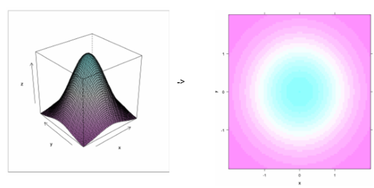

- Forme circulaire : Lorsque la densité est circulaire, cela signifie qu’aucune dimension ne domine l’autre, et qu’il n’y a pas de corrélation entre les variables. : Situation d’indépendance (comme en ACP, lorsque les axes sont orthogonaux et expliquent chacun la même part de variabilité).

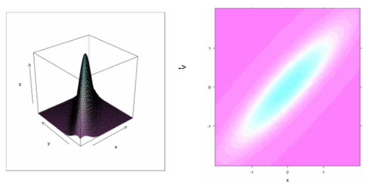

- Corrélation positive : Quand les données s’étirent le long d’une diagonale ascendante (de bas-gauche à haut-droit), cela indique une corrélation positive entre x et y. Par définition du coefficient de corrélation, les covariances (termes hors diagonale de la matrice) sont positives. Quand x augmente, y augmente aussi. Diapo 101 – Déplacement du vecteur des moyennes : Le centre de la distribution (μ1,μ2) s’est déplacé. Cela se traduit par un vecteur moyenne non nul (les valeurs de µ sont positives ou différentes de zéro).

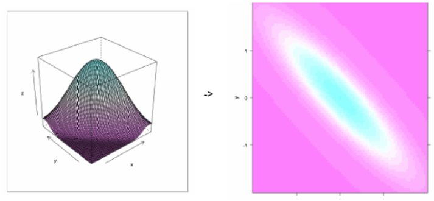

Diapo 103 – Corrélation négative : La forme de la distribution s’étire le long d’une diagonale descendante. La covariance est négative : quand une variable augmente, l’autre diminue. Les zones les plus denses (souvent en bleu sur les cartes de densité) correspondent aux régions les plus probables.

## 4.1 Interprétation du mélange

Chaque classe du modèle correspond à une loi gaussienne particulière. Le poids πk indique la proportion de cette classe dans la population totale.En combinant toutes les composantes pondérées par leurs πk, on obtient la densité totale du mélange.

## 4.2 P-valeur et hypothèse H₀

La p-valeur représente la probabilité d’obtenir une valeur d’observation aussi extrême (ou plus) que celle mesurée, sous l’hypothèse nulle H0. Une p-valeur faible indique que l’observation est peu probable si H0 est vraie. On a donc davantage de raisons de rejeter H0.

## 4.3 Approche du maximum de vraisemblance

L’estimation par maximum de vraisemblance (MLE) consiste à déterminer les paramètres inconnus (moyennes, variances, etc.) qui rendent les données observées les plus probables. - En 1 dimension, le paramètre estimé correspond à la moyenne. - En 2 dimensions, il s’agit du centre de gravité de la distribution.

Cette approche repose sur la fonction de vraisemblance, qui mesure la probabilité d’obtenir les observations pour un certain choix de paramètres.

Méthodologie : On a un échantillon de données X1, X2, …, Xn, qui sont supposées indépendantes et suivant une loi paramétrée par un ou plusieurs paramètres θ. La fonction de vraisemblance s’écrit :

$$L(\theta) = P(X_1 = x_1, \ldots, X_n =
x_n \mid \theta) = \prod_{i=1}^{n} f(x_i \mid \theta)$$

Afin de simplifier les calculs, on applique le logarithme. Ainsi maximiser la vraisemblance ou le log de la vraisemblance revient exactement au même, car la fonction log est strictement croissante. Ensuite, on dérive la fonction par rapport au paramètre θ et on annule cette dérivée pour trouver le maximum de la fonction.

Exemple appliqué : calcul de la fonction de vraisemblance et θ

Considérons un dé à 4 faces dont les probabilités dépendent d’un paramètre inconnu θ - P(1) = ½, - P(2) = θ , - P3 = 2θ et - P4 = ½ -3θ

Et α1 = nombre de 1, α2 = nombre de 2, α3 = nombre de 3, α4 = nombre de 4

Tout d’abord on écrit la fonction de vraisemblance :

$$L(θ) = C \ *\ P(1)^{α_1}\ * \ P(2)^{α_2}
* \ P(3)^{α_3} * \ P(4)^{α_4}$$

Ensuite on passe au log :
$$\ln L(\theta)
= \text{constante} + \alpha_1 \ln\left(\frac{1}{2}\right) + \alpha_2
\ln(\theta) + \alpha_3 \ln(2\theta) + \alpha_4 \ln\left(\frac{1}{2} -
3\theta\right)$$

Le log permet de transformer les produits en somme, donc de simplifier l’optimisation tout en préservant les maxima.

Puis on dérive par rapport à θ, qui est notre inconnue :
$$\frac{d\ell}{d\theta} = \frac{\alpha_2 +
\alpha_3}{\theta} - \frac{3\alpha_4}{\frac{1}{2} - 3\theta}$$

Puis on résout :
$$\hat{\theta} =
\frac{\alpha_2 + \alpha_3}{6(\alpha_2 + \alpha_3 +
\alpha_4)}$$

## 4.4 Probabilités conditionnelles / Théorème de Bayes

Lorsqu’un événement influence la probabilité d’un autre, on parle de probabilité conditionnelle.

Elle mesure la probabilité que A se produise, sachant que B est déjà réalisé.

Loi des probabilité totales : lorsqu’un événement peut se produire sous plusieurs conditions mutuellement exclusives B1, B2, …, Bk, on peut exprimer la probabilité totale de A par :

$$P(A) = \sum P(A | \ B_i) \ * \
P(B_i)$$

Le théorème de Bayes découle directement de la définition de la probabilité conditionnelle.

$$P(A\ |\ B) = \frac {P(B\ | \ A) * \
P(A)}{P(B)}$$

Le théorème permet de mettre à jour une probabilité à priori P(A) en fonction d’une nouvelle information B. P(A) : probabilité à priori (ce qu’on croit avant d’observer les données) P(B|A) : vraisemblance (la probabilité d’observer B si A est vrai) P(A|B) : probabilité à posteriori (la probabilité mise à jour après avoir observé B)

## 4.5 Exemple appliqué : Garage automobile

On cherche à acheter une voiture dans un garage, or certaines voiture ont une transmission défectueuse. On ne veut pas acheter une voiture défectueuse. Or, il n’est pas si simple de détecter les voitures qui sont défectueuses. Heureusement, on a un ami mécanicien (ouf!). Celui ci sait donner un diagnostic pour la voiture, mais ce diagnostic n’est pas parfait. En effet, quand il est en face d’une voiture dont la distribution est effectivement défectueuse, il saura faire le bon diagnostic (dire qu’elle l’est) à un certain niveau, et identiquement pour les voitures non défectueuses. Il y aura un risque associé à cette prédiction par le garagiste.

On cherche donc à savoir : quelle est l’apport d’avoir un ami mécanicien ?

On définit les événements suivants : - A : le mécanicien dit que la voiture est défectueuse - C1 : la transmission de la voiture est défectueuse. (resp. C2, la transmission de la voiture n’est pas défectueuse)

On sait que : - 30 % des voitures ont une transmission défectueuse : donc $P(C1)=0.3$ (resp. $P(C2)=0.7$) - le mécanicien donne le bon diagnostic pour 90 % des voitures défectueuses, c’est à dire que quand la transmission est effectivement défectueuse alors il y a 90 % de chances que le diagnostic soit correct (défaut détecté) soit $P(A|C_1)=0.9$ - et il donne le bon diagnostic à 80 % pour les voitures non défectueuses : quand la transmission est non défectueuse, il y a 80 % de chances que le diagnostic soit correct, soit $P(A|C_2)=0.8$

On veut calculer la probabilité que le mécanicien fasse un bon diagnostic pour notre voiture. Cela représente donc le risque associé à l’achat de ce véhicule. On veut le comparer avec P(C1), la probabilité a priori que le véhicule ait une transmission défectueuse, quand on a aucun diagnostic.

On va ainsi utiliser la loi des probabilités totales :
$$P(A) = P(A∣C_1) × P(C_1) + P(A∣C_2) × P(C_2) =
0,9 × 0,3 + 0,8 × 0,7 = 0,83$$

Le mécanicien fait donc un bon diagnostic dans 83 % des cas.

On cherche P(C1∣A), c’est-à-dire la probabilité qu’une voiture soit défectueuse sachant que le mécanitien dit qu’elle est défectueuse. Il s’agit de la probabilité a posteriori que la voiture soit défectueuse.

$$P(C_1∣A) =\frac {P(A∣C_1)×P(C_1)}
{P(A|C_1)* P(C_1)+\ P(A|C_2)* P(C_2) } =\frac {0,9×0,3}{0,83} =
0,33$$

La probabilité d’avoir une voiture défectueuse augmente légèrement après un bon diagnostic (de 30 % à 33 %). Le diagnostic est donc meilleur que le hasard. Si le diagnostic est que la voiture est, la probabilité d’avoir une voiture défectueuse est supérieure au hasard, donc le diagnostic a de la valeur. En effet, lorsque le mécanicien dit que la voiture est défectueuse, on a 33 % qu’elle soit défectueuse alors que sans aucune connaissance, on a 30 % de chances que la voiture soit défectueuse.

On cherche maintenant $P(C_1∣ \overline{A})$, c’est-à-dire la probabilité qu’une voiture soit défectueuse sachant que le diagnostic du mécanicien est que la voiture est non défectueuse. On voudrait que cette probabilité soit inférieure à la probabilité à priori que la voiture soit défectueuse (30%) car sinon le hasard serait plus utile que le diagnostic.

$P(\overline{A}∣C_1) = 1 - P(A∣C_1)$ = 1 - 0.9 = 0.1 $P(\overline{A}∣C_2) = 1 - P(A∣C_2)$ = 1 - 0.8 = 0.2

$$P(C_1∣ \overline{A}) =\frac
{P(\overline{A}∣C_1)×P(C_1)} {P(\overline{A}|C_1)* P(C_1)+\ P
(\overline{A}|C_2)* P(C_2) } =\frac {0,1×0,3}{0,1×0.3 \ + 0.2×0.7}
= 0,18$$

Pour conclure sur cet exemple, nous avons mis en évidence l’utilisation du théorème de Bayes et des probabilités conditionnelles

## 4.6 Exemple de la pièce défectueuse

Soit un lot de 4500 pièces – 3700 bonnes – 800 défectueuses

Réparties dans 4 boites – B1 : 2000 pièces (1600 bonnes, 400 défectueuses) – B2 : 500 pièces ( 300 bonnes, 200 défectueuses) – B3 : 1000 pièces ( 900 bonnes, 100 défectueuses) – B4 : 1000 pièces ( 900 bonnes, 100 défectueuses)

F = {tirer une pièce défectueuse}

Théorème de Bayes - Question : • Un événement A peut résulter de plusieurs causes Ck (s’excluant mutuellement), - Quelle est la probabilité de A connaissant – les probabilités élémentaires P(Ck) probabilités a priori – les probabilités conditionnelles de A à chaque cause Ck - Réponse = Théorème des probabilités totales

Méthode : On déduit des données d’entrées , les probabilités à priori qu’un pion pioché au hasard appartiennent à la boite 1, 2, 3 ou 4. Ces probabilités à posteriori correspondent directement aux fréquences du nb de pion par boite. $P(C_1) = \frac{2000}{4500}$ $P(C_2) = \frac{500}{4500}$ $P(C_3) = \frac{1000}{4500}$ $P(C_4) = \frac{1000}{4500}$

On calcule ensuite les probabilités conditionnelles $P(A|C_K)$ c’est à dire les probabilités sachant que si la pièce vient de la boite K , elle soit défectueuse. On utilise pour cela les fréquences de pièces défectueuses au sein de chaque boite.

$P(A|C_1) = \frac{1}{5}$ $P(A|C_2) = \frac{2}{5}$ $P(A|C_3) = 0.1$ $P(A|C_4) = 0.1$

On veut finalement calculer P(A), probabilité qu’une pièce tirée au hasard soit défectueuse.

$$P(A)= \sum^{K}_{k=1} P(C_K) \ * \
P(A|C_K) =
P(A|C_1) * P(C_1) \ + \ P(A|C_2) * P(C_2) \ + \ P(A|C_3) * P(C_3) \ + \
P(A|C_4) * P(C_4)$$

soit

$$P(A) = \frac{2000}{4500}*\frac{1}{5} \
+ \ \frac{500}{4500}*\frac{2}{5} \ + \ \frac{1000}{4500}*0.1 \ + \
\frac{1000}{4500}*0.1 =
0.088 + 0.044 + 0.022 + 0.022 = 0.18$$

La probabilité qu’une pièce tirée totalement au hasard soit défectueuse est de 18 %.

## 4.7 Exemple appliqué : Patients malades

On cherche a utiliser le théorème de Bayes et des probabilités totales dans le cadre d’une loi de probabilité. On sait que le statut malade / non malade d’un patient impacte la teneur en globule rouge d’un individu : en effet, le taux de globules rouges, noté X, d’un individu malade suit une loi Normale de paramètre µ = 30 ; $\sigma$ = 5 et celui d’un individu non malade suit une loi normale de paramètres µ = 27 ; $\sigma$ = 5.

On se demande si on peut savoir, à partir de ces connaissances biologiques, si un patient est malade, en connaissant seulement son taux de globules rouges ? Ou plutôt, quelle est sa probabilité d’appartenance au groupe “malade”, selon X, son taux de globules rouges.

On a : - X = taux de globule rouge variable continue - Y = état du patient, M=malade, NM=non malade - De manière générale : – f(X|M) ~ N (30, s2=5) – f(X|NM) ~ N (27,s2=5) - P(M) = 0.2 - P(NM) = 0.8

Un patient se présente avec X=24 … que vaut P(M|X=24) ?

On sait que $P(M) = 0.2$ & $P(NM) = 0.8$ donc il y a K = 2 classes (M et NM) et $\pi_K=(M, NM) = (0.2,0.8)$

$$P(M|X=24) = \frac {P(M) \ * \ P(X|M)
}{\sum^{K}_{k=1} \ P(K) \ * P(X|K) } =
\frac {P(M) \ * \ N(X,\mu_M,\sigma_M) }{\sum^{K}_{k=1} \ P(K) \ *
N(X,\mu_K,\sigma_K) } =
\frac {P(M) \ * \ N(X,\mu_M,\sigma_M) }{P(M) \ * N(X,\mu_M,\sigma_M)\
+\ P(NM) \ * N(X,\mu_{NM},\sigma_{NM})}$$

Pour calculer $N(X,\mu_M,\sigma_M)$ ; on utilise la fonction de densité d’une loi normale (programmée dans le cours 4 par la fonction “densité”). Cette fonction de densité donne pour tout x suivant une loi normale $N(\mu,\sigma)$ la valeur sur l’axe des ordonnées (‘hauteur’) => sur des portions de $x \in \ (a,b)$ on peut dériver f pour calculer l’aire sous la courbe => c’est la probabilité que X soit compris entre ces valeurs.

$f(X)=\frac{1}{\sigma \ * \sqrt(2\pi)} \ * \ \exp({-\frac{1}{2} (\frac{x - \ \mu}{\sigma})^2})$

On a donc :

$$P(M|X=24) = \frac {0.2 \ * \ 0.0388
}{0.2 \ * \ 0.0388 \ + \ 0.8 \ * \ 0.066 } = 0.12$$
Lorsque le taux de globules rouges d’un patient vaut 24, la probabilité que le patient soit malade est de 12 %. Cet exemple permet d’illustrer l’application de ces théorèmes au lois continues.

## 4.8 Exemple du dé, 20 ans après

Que vaut θ sachant que, le dé est tellement usé qu’il est impossible de différencier le 1du 2 (information cachée, variable latente) et on est tombé – x fois sur 1 ou 2 – α3 fois sur 3 – α4 fois sur 4.

Le lien avec les algorithme d’optimisation d’Expectation - Maximisation sont : Connaissant θ peut-on calculer la proportion de 1 (resp. de 2) à laquelle on peut raisonnablement s’attendre? (Expectation) Connaissant la proportion de 1 et de 2 il est facile de calculer θ ? (Maximization)

Commence-t-on par une étape d’E ? ou de M ?

On en déduit que x = $\alpha_1 + \alpha_2$ (on tire x fois 1, ou 2, sans pouvoir identifier si c’est 1 ou 2) et $\frac{\alpha_1}{\alpha_2} = \frac{1/2}{\theta} = \frac{1}{2 \theta}$

On isole $\alpha_1$ : $\alpha_1 = \frac{1/2 \ * \ x}{1/2 \ + \ \theta}$ et $\alpha_2$ : $\alpha_2 = \frac{\theta x}{1/2 \ + \ \theta}$

On peut faire quelques itérations semi - manuellement pour estimer $\theta$ à partir des valeurs de l’initialisation et des valeurs observées : - x = 20, α3 = 10, α4 = 10 - Initialisons θ à 0: θ(0) = 0

fonction qui calcule $\alpha_2$

```r
alpha2 <- function(x, t){
  a2 <- (t*x)/(0.5+t)
  return(a2)}
```

fonction de calcul de theta chapeau :

```r
theta_hat <- function(a2, a3, a4){
  t = (a2+a3)/(6*(a2+a3+a4))
  return(t)}
```

Initialisation θ(0) = 0 a2(0) = ?

```r
a2.0 <- alpha2(20,0) ; a2.0
```

```
## [1] 0
```

puis :

```r
t.1 <- theta_hat(0,10,10)
a2.1 <- alpha2(20, t.1)
```

et :

```r
t.2 <- theta_hat(a2.1, 10, 10)
a2.2 <- alpha2(20, t.2)
```

et :

```r
t.3 <- theta_hat(a2.2, 10, 10)
a2.3 <- alpha2(20, t.3)
```

et :

```r
t.4 <- theta_hat(a2.3, 10, 10)
a2.4 <- alpha2(20, t.4)
```

On voit que teta tend vers 0.094.

On applique un algorithme d’optimisation qui alterne : - une étape d’expectation qui attribue a chaque lancé où on a pioché 1;2 la probabilité que ce lancé appartienne à 1 ou à 2. - une étape de maximisation qui met à jour le paramètre $\theta$ à partir des probabilités d’appartenir à 1 ou à 2 (on veut s’arrêter quand on a estimé un paramètre le plus vraisemblable possible, il faudra donc définir un critère de convergence).

# 5 Seance 4

## 5.1 Algorithme EM

L’algorithme EM est une méthode d’optimisation itérative utilisée pour estimer les paramètres d’un modèle statistique lorsque certaines variables sont inobservées. Il est particulièrement utile pour les lois de mélanges, où chaque observation peut appartenir à plusieurs classes avec une certaine probabilités d’appartenance.

L’idée est d’alterner deux étapes :

1. E (Expectation) : estimer les probabilités d’appartenance des données aux différentes classes, connaissant les paramètres actuels.
2. M (Maximization) : mettre à jour les paramètres du modèles (moyennes, variances, poids, etc…) en utilisant les estimations obtenues à l’étape E.

Ces deux étapes sont répétées jusqu’à convergence, c’est-à-dire jusqu’à ce que les paramètres du modèle ne changent presque plus.

Déroulement de l’algorithme Initialisation : on part d’une distribution de valeurs observées. Les paramètres initiaux (moyennes, variances, poids des classes) sont choisis aléatoirement.

Etape E (Etiquetage) : connaissant les paramètres actuels (θ), on calcule, pour chaque observation, la probabilité d’appartenir à chaque classe. Autrement dit, on estime la proportion attendue d’individus appartenant à chaque classe. Ces probabilités servant à “étiqueter” les données de manière non stricte : une même observation peut appartenir partiellement à plusieurs classes.

Etape M (Maximisation des paramètres) : connaissant les probabilités d’appartenance calculées à l’étape précédente, on met à jour les paramètres θ du modèle (moyennes, écart-types)

Dans une loi de mélange, il n’y a pas d’appartenance stricte à une classe : chaque observation possède une probabilité d’appartenance à chacune des composantes du mélange. Les mises à jour des paramètres se font donc sous forme de moyennes pondérées par ces probabilités.

Étapes concrètes de génération d’un modèle de mélange : Générer un vecteur aléatoire représentant les observations Observer la distribution de ce vecteur Calculer les probabilités d’appartenance à chaque classe à partir des moyennes initiales Mettre à jour les moyennes des classes Répéter les étapes E et M jusqu’à stabilisation des résultats

## 5.2 Exemple de l’algorithme EM sur proba de dé

Considérons un dé à 4 faces dont les probabilités dépendent d’un paramètre inconnu θ  
- P(1) = ½,

- P(2) = θ ,

- P3 = 2θ et

- P4 = ½ -3θ

Et x = nombre de 1 et de 2, α3 = nombre de 3, α4 = nombre de 4

On note : x =α1 + α2 et
$$\frac{α1}{α2}=
\frac{1}{2θ}$$

Ainsi, on retrouve :
$$α1 = \frac{x}{2θ +
1}$$
et
$$α2 = \frac{2θx}{2θ +
1}$$

On a x = 20, α3 = 10 et α4 = 10

Initialisation θ(0) = 0, Etape E : α1 = 20 et α2 = 0 Etape M : θ(1) = 1/12

Puis on recalcule α1 et α2 avec la nouvelle valeur de θ, puis on calcule θ et ainsi de suite jusqu’à convergence.

## 5.3 Processus génératif de données et aux lois de mélange de gaussiennes bidimensionnelles

On s’intéresse aux processus génératif de données et aux lois de mélange de gaussiennes bidimensionnelles. Connaissant l’allure des données (histogramme des deux gaussiennes mélangées), on cherche à définir une solution d’initialisation de l’algorithme et d’alterner entre étapes d’expectation (calcul des probabilités d’appartenance de chaque point donné à l’une et l’autre gaussienne), et de maximisation (calcul à partir des probabilités d’appartenance à chaque gaussienne, des paramètres mis-à-jour des gaussiennes : µ et sigma), puis calcul des probabilités d’appartenance à chaque gaussienne avec paramètres mis à jour, et ré-estimation des paramètres des gaussiennes par pondération des probabilités d’appartenance de chaque point, jusqu’à convergence de l’algorithme (par rapport à un critère d’arrêt défini).

On commence par générer des un vecteur de données de taille 1 x 500 pour un autre groupe. Ce vecteur est généré à partir d’un mélange en proportions que l’on choisit de valeurs issues de deux lois normales de paramètres (mu, sigma) que l’on choisit.

On va créer une fonction pour générer automatiquement ce vecteur de taille 1x500 à partir des paramètres mu1, mu2 (moyennes des gaussiennes 1 et 2), sigma1, sigma2 (écarts types des gaussiennes 1 et 2), n1 et n2 (nombre de valeurs de la gaussienne 1 générées, resp. 2)

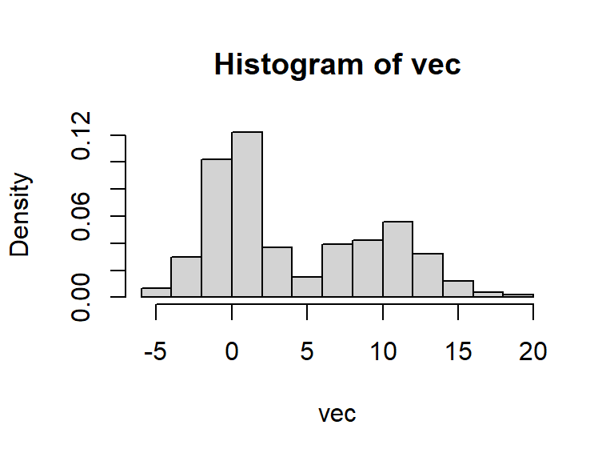

```r
# Fonction permettant de générer des données
f <- function(mu1, mu2, s1, s2, n1, n2) {
  vec1<- rnorm(n1,mu1, s1)
  vec2<- rnorm(n2,mu2, s2)
  vec <- sample(c(vec1, vec2))

  hist(vec, freq = F)

  return(vec)
}

res <- f(0, 10, 2, 3, 300, 200)
```

```r
res
```

```
##   [1]  8.422078082 13.317166612 -0.765341509  2.696184254  0.927789480
##   [6] 14.637246200 10.868519461  0.748409114  2.587380886  0.345619023
##  [11] 14.792717606  7.989729999  1.864458105 -0.139645318 -1.018492371
##  [16]  0.024678205 -0.174474796  1.897141769  0.643333297  8.937781977
##  [21] -1.016115427 -0.730392634 -1.235211362  0.297269451 -0.126423371
##  [26] -0.615615999 12.464699802  6.960553788  7.380006120 -0.819863868
##  [31] 12.808457730  6.037791788  0.806512453 12.166071013 -3.486405618
##  [36] 11.998327394 -0.123643614  7.852359381  8.331368418  1.895554144
##  [41] -3.758207544  6.286294955  0.011160119 -2.216372706  0.127496093
##  [46] 11.523632676  2.408252396 -2.213866796  7.344461504  1.008990328
##  [51] 12.821615825  2.086777168  8.525213139  9.364639607 10.477218569
##  [56] 13.653591835  0.160985780 11.004617989  8.391440838 -1.214840384
##  [61]  1.396601451 -4.981321260  2.368602122 10.223348011  7.810813068
##  [66] -1.118024383  1.229674648  7.129998097 -3.223652929 -0.783917230
##  [71] -1.560103148  0.140320028 14.366923833  2.370384633  9.751056093
```

[output cut: 85 more lines]

```r
# envoi du vecteur
# write.csv(res, 'res.csv')
```

### 5.3.1 Chargement des données reçues du groupe 4

On reçoit d’un autre groupe de la classe un vecteur de taille 1x500, similairement généré par mélange de deux gaussiennes.

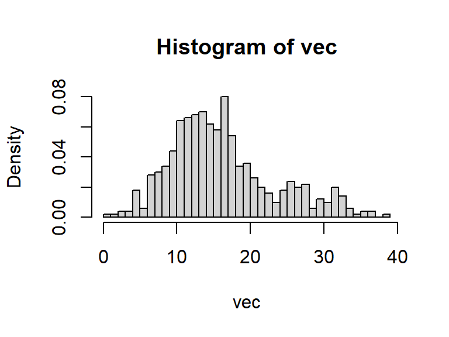

```r
# Visualisation des données du vecteur
vec <- read.table("data/vecteur_4.csv", sep = ",")
vec <- vec$V2
vec <- vec[-1]
vec <- sapply(vec, as.numeric)

hist(vec, nclass = 50, freq = F)
```

### 5.3.2 Initialisation de l’algorithme

On choisit des vecteurs de paramètres permettant d’initialiser l’algorithme. On choisit $N(14,5)$ et $N(26,10)$.

Cette fonction appelée fonction de répartition de la loi gaussienne modélise l’histogramme cumulatif d’une distribution en cloche.

Elle donne en chaque point donné x ; $x \in (-\infty \ ; \ +\infty)$) la valeur de f(x) correspondante. On sait que par définition la probabilité qu’un x soit compris entre a <= x <= b correspond à la dérivée de f(x) (f’(x)) de a à b, c’est-à-dire l’aire sous la courbe de f de a à b.

On commence par calculer en trois points, définis plus hauts, la densité de la fonction en chacun de ces points, s’ils appartenaient à la gaussienne 1 et s’ils appartenaient à la gaussienne 2. On fixe en effet la classe comme s’il s’agissait de la classe réelle. Plus la densité est élevée, plus le point sera proche du ‘pic’ de la gaussienne (donc de sa moyenne), donc plus la probabilité que ce point appartienne à cette gaussienne sera élévée, car observée cette valeur de x sous l’hypothèse nulle sera très probable. Au contraire, si la densité est très faible, alors la probabilité qu’un tel x appartenant à cette distribution ait été observé sous l’hypothèse nul est très faible.

Si le rapport des densités d1/d2 pour un x donné est supérieur à 1, alors il est plus probable que le point x appartienne à la gaussienne 1 qu’à la gaussienne 2 (et respectivement à la gaussienne 2 si d1/d2 est inféieur à 1).

On définit une fonction qui calcule la densité de x selon les paramètres $\mu \ ; \ \sigma$ de la gaussienne.

```r
densite <- function(sigma, mu, x) {
  d <- (1/(sigma*sqrt(2*pi)))  * exp((-1/2)*  ((x-mu)/sigma)^2)
  return(d)
}
```

On définit les vecteurs de paramètres d’initialisation

```r
mu1.1 <- 14
mu2.1 <- 26
s1.1 <- 5
s2.1 <- 10
```

On calcule pour chacun des trois points choisis la densité de f(x) selon les vecteurs de paramètres d’initialisation choisis.

```r
# Pour x = 12
d.1.12 <- densite(sigma = s1.1, mu = mu1.1, x = 12)
d.2.12 <- densite(sigma = s2.1, mu = mu2.1, x = 12)
d.1.12/d.2.12  # > 1
```

```
## [1] 4.919206
```

```r
# pour x = 20
d.1.20 <- densite(sigma = s1.1, mu = mu1.1, x = 20)
d.2.20 <- densite(sigma = s2.1, mu = mu2.1, x = 20)
d.1.20/d.2.20 # > 1
```

```
## [1] 1.165497
```

```r
# pour x = 25
d.1.25 <- densite(sigma = s1.1, mu = mu1.1, x = 25)
d.2.25 <- densite(sigma = s2.1, mu = mu2.1, x = 25)
d.1.25/d.2.25 # < 1
```

```
## [1] 0.1787347
```

Le point proche du pic de la gaussienne 1 ainsi que le point au milieu entre les deux pics des deux gaussiennes sont plus probables d’appartenir à la distribution de la gaussienne 1. Le point proche du pic de la gaussienne 2 appartient plus probablement à la gaussienne 2.

Or, on ne connait pas les paramètres réels des deux gaussiennes, on veut les estimer.

On va donc étendre à tout le vecteur de valeur l’étape E, permettant d’associer chaque valeur du vecteur avec une probabilité d’appartenir à la distribution 1 et respectivement à la distribution 2. On va ensuite appliquer une étape de l’algorithme M, permettant à partir des moyennes pondérées de recalculer une meilleure estimation des vecteurs de paramètres des gaussiennes 1 et 2, puis répéter ces deux opérations jusqu’à convergence de l’algorithme.

### 5.3.3 Etape E

L’objectif de l’étape E est d’étiquetter chacune des valeurs du vecteur *res* avec une probabilité d’appartenance à chacune des gaussiennes associé à son vecteur de paramètre initialisé.

On va calculer en chaque point du vecteur, et donc en chaque x, la densité de la fonction si le point x appartient à la gaussienne 1, et idem si le point x appartient à la gaussienne 2. De cette façon, on fixe l’appartenance de x à chacune des deux gaussiennes, donc calculer cette densité revient à calculer :

- P(A|C1) : la probabilité pour que un individu qui appartient à la classe 1 soit classé comme appartenant à la classe 1
- et resp. P(A|C2) : la probabilité qu’un individu de la classe 2 soit classé comme appartenant à la classe 2 (bien classé)

A partir de tous les calculs de densité d1 et d2, en chaque point du vecteur, on peut calculer pour chaque point s’il est plus probable qu’il appartienne à la gaussienne 1 ou à la gausienne 2. Ainsi, sur l’ensemble des 500 valeurs du vecteur *res* , on peut calculer la probabilité à posteriori d’appartenir à la classe 1 (gaussienne 1) ou à la classe 2 (gausseinne 2).

P(C1) : probabilité d’appartenir à la classe 1 P(C2) : probabilité d’appartenir à la classe 2

Or nous ne connaissons pas n1 et n2. Ainsi, nous estimons P(C1) et P(C2) à partir du nombre de valeurs du vecteur de données pour lequel $\frac{d1}{d2} > 1$ . La somme de ces valeurs correspond à P(C1).

Par la formule de bayes, on sait que :

avec :

- $P(C_1|A)$ : proba qu’un individu classé comme appartenant à la gaussienne 1 appartienne réellement à la gaussienne 1
- $P(A|C_1)$ : proba qu’un individu appartenant réellement à C1 soit classé comme appartenant à C1 (resp. C2)
- $P(C_1)$ : probabilité d’appartenir à C1 (resp. C2)

```r
etapeE <- function (vec, mu1, mu2, s1, s2) {
  # la fonction etapeE prend en entrée :
  #   - un vecteur de valeurs
  #   - les paramètres initialisés (ou réestimés) des deux gaussiennes

  # initialisation de la matrice
  mat <- matrix(0, nrow = length(vec), ncol=2)
  # cette matrice de longueur 500 (taille du vecteur vec) accueillera dans ses colonnes 1 et 2 les valeurs des probabilités que la valeur i du vecteur vec appartienne à la gaussienne 1 et à la gaussienne 2. Chaque ligne i de la matrice somme donc à 1 avec chaque élément des colonnes 1 et 2 compris entre 0 et 1.

  # On initialise deux vecteurs d1 et d2
  # d1 (resp. d2) accueillera les valeurs des densités de chacun des x du vecteur *vec* s'il appartient à la gausienne 1 (de paramètres mu1 et s1) (et resp. 2, de paramètres mu2 et s2)
  d1 <- NULL
  d2 <- NULL

  # calcul des densités du vecteur vec pour g1 et g2
  for (i in 1:length(vec)){
    d1[i] <- densite(sigma = s1, mu = mu1, x = vec[i] )
    d2[i] <- densite(sigma = s2, mu = mu2, x = vec[i] )
  }

  # print(d1)  # test d1
  # print(d2)  # test d2

  # on va compter les d1/d2
  compteur1 <- NULL
  for (i in 1:length(d1)){
    if (d1[i]>d2[i]) {
      compteur1[i] <- TRUE
    }
  }

  # print(compteur1)
  # soit TRUE soit 'na'

  C1 <- sum(!is.na(compteur1)) ; # print(C1)
  C2 <- length(vec)-C1

  p.C1 <- C1 / (C1+C2)
  p.C2 <- C2 / (C1+C2)

  # print(p.C1)
  # print(p.C2)
  # P(A| C1)  = d1

  p.A.C1 <- d1
  p.A.C2 <- d2

  # Remplissage de la matrice *mat* avec les proba P(C1|A) et P(C2|A)
  for (i in 1:nrow(mat)) {
  mat[i,1] <- (p.A.C1[i] * p.C1) / (  p.A.C1[i]*p.C1 +    p.A.C2[i]*p.C2 )

  mat[i,2] <- ( p.A.C2[i] * p.C2) / ( p.A.C1[i]*p.C1 +    p.A.C2[i]*p.C2 )

  }

  return(list(mat, p.C1, p.C2))
  # on retourne la matrice contenant les proba d'appartenance de chaque individu à l'une et l'autre gaussiennes
}
```

Etape E - initialisation de l’algorithme

```r
res.E.1 <- etapeE(vec, mu1.1, mu2.1, s1 = s1.1, s2 = s2.1)
# res.E.1[[1]]
```

### 5.3.4 Etape M

Pour l’étape M, on part du vecteur de données et de la matrice obtenue à l’étape E précédente.

```r
etapeM <- function(vecteur,matrice){

  moyenne <- numeric(ncol(matrice))
  ecarts_type <- numeric(ncol(matrice))

  for (j in 1:ncol(matrice)){
    haut <- 0
    bas <- 0
    somme <- 0

    for (i in 1:nrow(matrice)){
      haut <-haut + vecteur[i]*matrice[i,j]
      bas <- bas + matrice[i,j]
    }

    moyenne[j] <- haut/bas

    for (i in 1:nrow(matrice)) {
      somme <- somme + matrice[i,j] * (vecteur[i] - moyenne[j])^2
    }
    ecarts_type[j] <- sqrt(somme / bas)
  }
  return(list(vec = vecteur,mu1 = moyenne[1], mu2 = moyenne[2], s1= ecarts_type[1], s2 = ecarts_type[2]))
}
```

Etape M - initialisation

```r
res.M.1 <- etapeM(vec, res.E.1[[1]])
```

### 5.3.5 Alternance des étapes E et M et convergence de l’algorithme

On créé une fonction qui, à partir des éléments suivants en entrée : - vec : vecteur de valeurs - nb_iter : nombre d’itérations de l’algorithme à réaliser - mu1.init, mu2.init, s1.init, s2.init les valeurs initiales des gaussiennes démélangées

Cette fonction réalise l’étape E et calcule pour chaque valeur du vecteur *vec* les probabilités d’appartenance aux gaussiennes 1 et 2, comme vu précédemment.

La fonction etapeM est ensuite utilisée pour calculer à partir de ce vecteur et de la matrice obtenue grâce à l’étape E; les moyennes et écarts types pondérés mis à jour, donc réestimés à cette étape. Cette fonction sort une liste qui contient le vecteur ainsi que les couples de paramètres $(\mu_1 \ , \ \sigma_1)$ et $(\mu_2 \ , \ \sigma_2)$.

A l’étape suivante, l’étape E est à nouveau réalisée à partir des valeurs mises à jour des paramètres des gaussiennes démélangées. Et les valeurs de ces paramètres sont réestimés à l’étape M avec la matrice des probabilités d’appartenance de chaque individu à chacune des gaussiennes dont les paramètres ont été estimés à l’étape M précédente. On réalise ces étapes jusqu’à atteindre le nombre d’itérations donné en entrée.

```r
etapesEM <- function (vec, nb_iter, mu1.init = mu1.1, mu2.init = mu2.1, s1.init = s1.1, s2.init = s2.1 ) {

  num_iter <- 0

  # initialisation
  cat("réalisation de l'étape :", num_iter)
  resE <- etapeE(vec, mu1.1, mu2.1, s1.1, s2.1)
  resM <- etapeM(vec, matrice = resE[[1]])
  cat("\tNouvelles valeurs : mu1 =",round(resM[[2]]),"|", "mu2 =",round(resM[[3]]),"|", "s1 = ",round(resM[[4]]),"|", "s2 =", round(resM[[5]]))
  num_iter= num_iter + 1

  # itérations
  while(num_iter!=nb_iter) {
  cat("\nréalisation de l'étape :", num_iter)
  resE <- etapeE(vec = resM[[1]], mu1 = resM[[2]], mu2 = resM[[3]], s1 = resM[[4]], s2 = resM[[5]])
  resM <- etapeM(vecteur = resM[[1]], matrice = resE[[1]])
  cat("\tNouvelles valeurs : mu1 =",round(resM[[2]]),"|", "mu2 =",round(resM[[3]]),"|", "s1 = ",round(resM[[4]]),"|", "s2 =", round(resM[[5]]))
  num_iter= num_iter + 1
  }

}
```

Test de la fonction d’itération

```r
etapesEM(vec = vec, nb_iter = 100)
```

```
## réalisation de l'étape : 0   Nouvelles valeurs : mu1 = 14 | mu2 = 25 | s1 =  5 | s2 = 8
## réalisation de l'étape : 1   Nouvelles valeurs : mu1 = 13 | mu2 = 24 | s1 =  5 | s2 = 7
## réalisation de l'étape : 2   Nouvelles valeurs : mu1 = 13 | mu2 = 24 | s1 =  4 | s2 = 7
## réalisation de l'étape : 3   Nouvelles valeurs : mu1 = 13 | mu2 = 24 | s1 =  4 | s2 = 7
## réalisation de l'étape : 4   Nouvelles valeurs : mu1 = 13 | mu2 = 24 | s1 =  4 | s2 = 6
## réalisation de l'étape : 5   Nouvelles valeurs : mu1 = 13 | mu2 = 24 | s1 =  4 | s2 = 6
## réalisation de l'étape : 6   Nouvelles valeurs : mu1 = 13 | mu2 = 24 | s1 =  4 | s2 = 6
## réalisation de l'étape : 7   Nouvelles valeurs : mu1 = 13 | mu2 = 24 | s1 =  4 | s2 = 6
## réalisation de l'étape : 8   Nouvelles valeurs : mu1 = 13 | mu2 = 25 | s1 =  4 | s2 = 6
## réalisation de l'étape : 9   Nouvelles valeurs : mu1 = 13 | mu2 = 25 | s1 =  4 | s2 = 6
## réalisation de l'étape : 10  Nouvelles valeurs : mu1 = 13 | mu2 = 25 | s1 =  4 | s2 = 6
## réalisation de l'étape : 11  Nouvelles valeurs : mu1 = 13 | mu2 = 25 | s1 =  4 | s2 = 6
## réalisation de l'étape : 12  Nouvelles valeurs : mu1 = 13 | mu2 = 25 | s1 =  4 | s2 = 6
## réalisation de l'étape : 13  Nouvelles valeurs : mu1 = 13 | mu2 = 25 | s1 =  4 | s2 = 6
## réalisation de l'étape : 14  Nouvelles valeurs : mu1 = 13 | mu2 = 25 | s1 =  4 | s2 = 6
## réalisation de l'étape : 15  Nouvelles valeurs : mu1 = 13 | mu2 = 25 | s1 =  4 | s2 = 6
## réalisation de l'étape : 16  Nouvelles valeurs : mu1 = 13 | mu2 = 25 | s1 =  4 | s2 = 6
## réalisation de l'étape : 17  Nouvelles valeurs : mu1 = 13 | mu2 = 25 | s1 =  4 | s2 = 6
## réalisation de l'étape : 18  Nouvelles valeurs : mu1 = 13 | mu2 = 25 | s1 =  4 | s2 = 6
## réalisation de l'étape : 19  Nouvelles valeurs : mu1 = 13 | mu2 = 25 | s1 =  4 | s2 = 6
## réalisation de l'étape : 20  Nouvelles valeurs : mu1 = 13 | mu2 = 25 | s1 =  4 | s2 = 6
## réalisation de l'étape : 21  Nouvelles valeurs : mu1 = 13 | mu2 = 25 | s1 =  4 | s2 = 6
## réalisation de l'étape : 22  Nouvelles valeurs : mu1 = 13 | mu2 = 25 | s1 =  4 | s2 = 6
## réalisation de l'étape : 23  Nouvelles valeurs : mu1 = 13 | mu2 = 25 | s1 =  4 | s2 = 6
## réalisation de l'étape : 24  Nouvelles valeurs : mu1 = 13 | mu2 = 25 | s1 =  4 | s2 = 6
## réalisation de l'étape : 25  Nouvelles valeurs : mu1 = 13 | mu2 = 25 | s1 =  4 | s2 = 6
## réalisation de l'étape : 26  Nouvelles valeurs : mu1 = 13 | mu2 = 25 | s1 =  4 | s2 = 6
## réalisation de l'étape : 27  Nouvelles valeurs : mu1 = 13 | mu2 = 25 | s1 =  4 | s2 = 6
## réalisation de l'étape : 28  Nouvelles valeurs : mu1 = 13 | mu2 = 25 | s1 =  4 | s2 = 6
## réalisation de l'étape : 29  Nouvelles valeurs : mu1 = 13 | mu2 = 25 | s1 =  4 | s2 = 6
## réalisation de l'étape : 30  Nouvelles valeurs : mu1 = 13 | mu2 = 25 | s1 =  4 | s2 = 6
## réalisation de l'étape : 31  Nouvelles valeurs : mu1 = 13 | mu2 = 25 | s1 =  4 | s2 = 6
## réalisation de l'étape : 32  Nouvelles valeurs : mu1 = 13 | mu2 = 25 | s1 =  4 | s2 = 6
## réalisation de l'étape : 33  Nouvelles valeurs : mu1 = 13 | mu2 = 25 | s1 =  4 | s2 = 6
## réalisation de l'étape : 34  Nouvelles valeurs : mu1 = 13 | mu2 = 25 | s1 =  4 | s2 = 6
## réalisation de l'étape : 35  Nouvelles valeurs : mu1 = 13 | mu2 = 25 | s1 =  4 | s2 = 6
## réalisation de l'étape : 36  Nouvelles valeurs : mu1 = 13 | mu2 = 25 | s1 =  4 | s2 = 6
## réalisation de l'étape : 37  Nouvelles valeurs : mu1 = 13 | mu2 = 25 | s1 =  4 | s2 = 6
## réalisation de l'étape : 38  Nouvelles valeurs : mu1 = 13 | mu2 = 25 | s1 =  4 | s2 = 6
## réalisation de l'étape : 39  Nouvelles valeurs : mu1 = 13 | mu2 = 25 | s1 =  4 | s2 = 6
```

[output cut: 45 more lines]

```
## réalisation de l'étape : 85  Nouvelles valeurs : mu1 = 13 | mu2 = 25 | s1 =  4 | s2 = 6
## réalisation de l'étape : 86  Nouvelles valeurs : mu1 = 13 | mu2 = 25 | s1 =  4 | s2 = 6
## réalisation de l'étape : 87  Nouvelles valeurs : mu1 = 13 | mu2 = 25 | s1 =  4 | s2 = 6
## réalisation de l'étape : 88  Nouvelles valeurs : mu1 = 13 | mu2 = 25 | s1 =  4 | s2 = 6
## réalisation de l'étape : 89  Nouvelles valeurs : mu1 = 13 | mu2 = 25 | s1 =  4 | s2 = 6
## réalisation de l'étape : 90  Nouvelles valeurs : mu1 = 13 | mu2 = 25 | s1 =  4 | s2 = 6
## réalisation de l'étape : 91  Nouvelles valeurs : mu1 = 13 | mu2 = 25 | s1 =  4 | s2 = 6
## réalisation de l'étape : 92  Nouvelles valeurs : mu1 = 13 | mu2 = 25 | s1 =  4 | s2 = 6
## réalisation de l'étape : 93  Nouvelles valeurs : mu1 = 13 | mu2 = 25 | s1 =  4 | s2 = 6
## réalisation de l'étape : 94  Nouvelles valeurs : mu1 = 13 | mu2 = 25 | s1 =  4 | s2 = 6
## réalisation de l'étape : 95  Nouvelles valeurs : mu1 = 13 | mu2 = 25 | s1 =  4 | s2 = 6
## réalisation de l'étape : 96  Nouvelles valeurs : mu1 = 13 | mu2 = 25 | s1 =  4 | s2 = 6
## réalisation de l'étape : 97  Nouvelles valeurs : mu1 = 13 | mu2 = 25 | s1 =  4 | s2 = 6
## réalisation de l'étape : 98  Nouvelles valeurs : mu1 = 13 | mu2 = 25 | s1 =  4 | s2 = 6
## réalisation de l'étape : 99  Nouvelles valeurs : mu1 = 13 | mu2 = 25 | s1 =  4 | s2 = 6
```